# Welcome to the S-I-S

Last edited on 08 May, 2025

[School](https://dle.plymouth.ac.uk/course/view.php?id=66067) - [Programme](https://dle.plymouth.ac.uk/course/view.php?id=38727) - [S4](https://plymuni.lightning.force.com/lightning/page/home) - [Gradbook](https://gradbook.plymouth.ac.uk/) - [RoomBooking](https://resourcebooker.plymouth.ac.uk/) - [Timetable](https://timetables.plymouth.ac.uk/) - [Panopto](https://plymouth.cloud.panopto.eu/) - [TechOffice](https://psy.plymouth.ac.uk) - [Primo](https://primo.plymouth.ac.uk) - [SONA](https://uopsop.sona-systems.com/)

[figure not shown]

This site preserves the former School Information Site, codesigned with new staff to provide a single source of information about the School of Psychology at the University of Plymouth.

# 1 Quick Links to Modules

[School](https://dle.plymouth.ac.uk/course/view.php?id=66067) - [Programme](https://dle.plymouth.ac.uk/course/view.php?id=38727) - [Gradbook](https://gradbook.plymouth.ac.uk/) - [RoomBooking](https://resourcebooker.plymouth.ac.uk/) - [Timetable](https://timetables.plymouth.ac.uk/) - [Panopto](https://plymouth.cloud.panopto.eu/) - [SONA](https://uopsop.sona-systems.com/)

This section provides direct links to the 2024-25 DLE sites and S4 pages for all programmes and modules. It is organised by Programme, so also provides an overview of all teaching.

The [2023-24](https://discourse.psy.plymouth.ac.uk/t/quick-access-to-dle-and-s4-pages/1365), [2022-23](https://liveplymouthac.sharepoint.com/sites/u70/SitePages/DLE%20Quick%20Access%202022-23.aspx), [2021-22](https://liveplymouthac.sharepoint.com/sites/u70/SitePages/DLE%20Quick%20Access%202021-22.aspx) and [2020-21](https://liveplymouthac.sharepoint.com/sites/u70/SitePages/Psychology%20DLE%20sites%202020-21.aspx) sessions are still online. For earlier years, use the [DLE Site Home](https://dle.plymouth.ac.uk/?redirect=0) Search box - type module code and year e.g., ‘PSYC204 18’

## [School of Psychology DLE](https://dle.plymouth.ac.uk/course/view.php?id=66067) (including office hours)

## [Foundation Year](https://dle.plymouth.ac.uk/course/view.php?id=51939) (PL: Sophie Homer)

**Semester 1:** [001 Foundations](https://dle.plymouth.ac.uk/local/permalink?id=PSYC001-24/AU/SB/M) [**S4**](https://plymuni.lightning.force.com/lightning/r/Module_Cohort__c/a3867000003go3kAAA/view) (Sophie Homer) - [002 Everyday](https://dle.plymouth.ac.uk/local/permalink?id=PSYC002-24/AU/SB/M) [**S4**](https://plymuni.lightning.force.com/lightning/r/Module_Cohort__c/a3867000003go3lAAA/view) (Sophie Homer)

**Semester 2:** [003 Health & Behaviour](https://dle.plymouth.ac.uk/local/permalink?id=PSYC003-24/SP/SB/M) [**S4**](https://plymuni.lightning.force.com/lightning/r/Module_Cohort__c/a3867000003go3zAAA/view) (Andy Wills) - [005 Connecting Psychology](https://dle.plymouth.ac.uk/local/permalink?id=PSYC005-24/SP/SB/M) [**S4**](https://plymuni.lightning.force.com/lightning/r/Module_Cohort__c/a38Sh0000018ChqIAE/view) (Zahra Hussain)

## [BSc/MPsych Psychology](https://dle.plymouth.ac.uk/course/view.php?id=38727) **PL: Peter Jones**

*Stage 1 Semester 1* - [421 Cognitive](https://dle.plymouth.ac.uk/local/permalink?id=PSYC421-24/AU/M) Chris Berry [**S4-link**](https://plymuni.lightning.force.com/lightning/r/Module_Cohort__c/a38Sh000000FWD2IAO/view) - [422 Clinical and Developmental](https://dle.plymouth.ac.uk/local/permalink?id=PSYC422-24/AU/SB/M) Ed Symes [**S4-link**](https://plymuni.lightning.force.com/lightning/r/Module_Cohort__c/a38Sh000000FWD4IAO/view) - [423 Environmental](https://dle.plymouth.ac.uk/local/permalink?id=PSYC423-24/AU/M) Kayleigh Wyles [**S4-link**](https://plymuni.lightning.force.com/lightning/r/Module_Cohort__c/a38Sh000000FWD3IAO/view)

*Stage 1 Semester 2* - [424 Social](https://dle.plymouth.ac.uk/local/permalink?id=PSYC424-24/SP/SU/M) Mila Mileva [**S4-link**](https://plymuni.lightning.force.com/lightning/r/Module_Cohort__c/a38Sh000000FWD1IAO/view) - [425 Perception and Brain](https://dle.plymouth.ac.uk/local/permalink?id=PSYC425-24/SP/SB/M) Zahra Hussain [**S4-link**](https://plymuni.lightning.force.com/lightning/r/Module_Cohort__c/a38Sh000000FWD5IAO/view) - [426 Motivation and Performance](https://dle.plymouth.ac.uk/local/permalink?id=PSYC426-24/SP/SU/M) Jon Rhodes [**S4-link**](https://plymuni.lightning.force.com/lightning/r/Module_Cohort__c/a38Sh000000FWD0IAO/view)

*Stage 2 Semester 1* - [514 ID, Soc & Dev](https://dle.plymouth.ac.uk/local/permalink?id=PSYC514-24/AU/SB/M) Jaysan Charlesford [**S4-link**](https://plymuni.lightning.force.com/lightning/r/Module_Cohort__c/a3867000003gnnQAAQ/view) - [515 Health and Wellbeing](https://dle.plymouth.ac.uk/local/permalink?id=PSYC515-24/AU/SB/M) Julie Ji [**S4-link**](https://plymuni.lightning.force.com/lightning/r/Module_Cohort__c/a3867000003gnnOAAQ/view) - [519 RMiP1](https://dle.plymouth.ac.uk/local/permalink?id=PSYC519-24/AU/SB/M) and [Metasite](https://dle.plymouth.ac.uk/course/view.php?id=78854) Ben Whalley [**S4-link**](https://plymuni.lightning.force.com/lightning/r/Module_Cohort__c/a3867000003gnnRAAQ/view)

*Stage 2 Semester 2* - [513 Cognitive and Biological](https://dle.plymouth.ac.uk/local/permalink?id=PSYC513-24/SP/SB/M) Michael Verde [**S4-link**](https://plymuni.lightning.force.com/lightning/r/Module_Cohort__c/a3867000003gnnVAAQ/view) - [516 Applied Psychology](https://dle.plymouth.ac.uk/local/permalink?id=PSYC516-24/SP/SB/M) Steve Minton [**S4-link**](https://plymuni.lightning.force.com/lightning/r/Module_Cohort__c/a3867000003gnnTAAQ/view) - [520 RMiP2](https://dle.plymouth.ac.uk/local/permalink?id=PSYC520-24/SP/SB/M) and [shared-content site](https://dle.plymouth.ac.uk/local/permalink?id=PSYC520_X-24/SP/SB/M) Julien Besle [**S4-link**](https://plymuni.lightning.force.com/lightning/r/Module_Cohort__c/a3867000003gnnUAAQ/view)

*Stage 4* - [601 Options 1](https://dle.plymouth.ac.uk/local/permalink?id=PSYC601-24/AU/SB/M) Gustav Kuhn [**S4-link**](https://plymuni.lightning.force.com/lightning/r/Module_Cohort__c/a3867000003gnnaAAA/view) - [602 Options 2](https://dle.plymouth.ac.uk/local/permalink?id=PSYC602-24/AU/SB/M) Gustav Kuhn [**S4-link**](https://plymuni.lightning.force.com/lightning/r/Module_Cohort__c/a3867000003gnnYAAQ/view) - [603 Options 3](https://dle.plymouth.ac.uk/local/permalink?id=PSYC603-24/SP/SB/M) Jan Woike [**S4-link**](https://plymuni.lightning.force.com/lightning/r/Module_Cohort__c/a3867000003gnncAAA/view) - [604 Options 4](https://dle.plymouth.ac.uk/local/permalink?id=PSYC604-24/SP/SB/M) Jan Woike [**S4-link**](https://plymuni.lightning.force.com/lightning/r/Module_Cohort__c/a3867000003gnneAAA/view) - [605 Dissertation](https://dle.plymouth.ac.uk/local/permalink?id=PSYC605-24/AY/AU/M) Matt Roser [**S4-link**](https://plymuni.lightning.force.com/lightning/r/Module_Cohort__c/a3867000003gnnWAAQ/view)

## Minors student modules

*Stage 1* - Semester 1 [PSYC419 Cognitive Psychology and Applied Psychological Research](https://dle.plymouth.ac.uk/local/permalink?id=PSYC419-24/AU/SB/M) - Chris Longmore [**S4**](https://plymuni.lightning.force.com/lightning/r/Module_Cohort__c/a3867000003go8fAAA/view) - Semester 2 [PSYC420 Social and Developmental Psychology](https://dle.plymouth.ac.uk/local/permalink?id=PSYC420-24/SP/SB/M) - Mila Mileva [**S4**](https://plymuni.lightning.force.com/lightning/r/Module_Cohort__c/a3867000003gqDpAAI/view) - Semester 2 [PSYC427 Health Behaviour](https://dle.plymouth.ac.uk/local/permalink?id=PSYC427-24/SP/SB/M) - Jon Rhodes [**S4**](https://plymuni.lightning.force.com/lightning/r/Module_Cohort__c/a38Sh00000147K5IAI/view)

*Stage 2* - Semester 1 [PSYC521 Biological Basis of Behaviour](https://dle.plymouth.ac.uk/local/permalink?id=PSYC521-24/AU/SB/M) - Mathew Hudson [**S4**](https://plymuni.lightning.force.com/lightning/r/Module_Cohort__c/a3867000003gnnPAAQ/view) - Semester 2 [PSYC522 Individual Differences in Behaviour](https://dle.plymouth.ac.uk/local/permalink?id=PSYC522-24/SP/SB/M) - Jon May [**S4**](https://plymuni.lightning.force.com/lightning/r/Module_Cohort__c/a3867000003gnnSAAQ/view)

*Stage 4* - Semester 1 [PSYC608 Applied Topics in Psychology 1](https://dle.plymouth.ac.uk/local/permalink?id=PSYC608-24/AU/SB/M) - Matt Hudson [**S4**](https://plymuni.lightning.force.com/lightning/r/Module_Cohort__c/a3867000003gnnXAAQ/view) - Semester 2 [PSYC609 Applied Topics in Psychology 2](https://dle.plymouth.ac.uk/local/permalink?id=PSYC609-24/SP/SB/M) - Matt Hudson [**S4**](https://plymuni.lightning.force.com/lightning/r/Module_Cohort__c/a3867000003gnndAAA/view)

## Zero Credit UG Modules

[CPIE202 Careers and Placement planning](https://dle.plymouth.ac.uk/local/permalink?id=CPIE202-24/AY/AU/M) - Lindsay Marshall [**S4**](https://plymuni.lightning.force.com/lightning/r/Module_Cohort__c/a3867000003gnnMAAQ/view) [CPIE501 Placement Year](https://dle.plymouth.ac.uk/local/permalink?id=CPIE501-24/AY/AU/M) - Ed Symes [**S4**](https://plymuni.lightning.force.com/lightning/r/Module_Cohort__c/a3867000003gnj0AAA/view) [PSYC600 Careers Planning](https://dle.plymouth.ac.uk/local/permalink?id=PSYC600-24/AY/AU/M) - Peter Jones [**S4**](https://plymuni.lightning.force.com/lightning/r/Module_Cohort__c/a3867000003gnnNAAQ/view)

## [MSc Psychology (Conversion)](https://dle.plymouth.ac.uk/course/view.php?id=38758) (PL: Sonja Heintz)

*Semester 1:* [704 ID/Soc/Dev](https://dle.plymouth.ac.uk/local/permalink?id=PSYC704-24/AU/SB/M) [**S4**](https://plymuni.lightning.force.com/lightning/r/Module_Cohort__c/a3867000003go45AAA/view) (Jaysan Charlesford) - taught with PSYC514 [705 Health & Wellbeing](https://dle.plymouth.ac.uk/local/permalink?id=PSYC705-24/AU/SB/M) [**S4**](https://plymuni.lightning.force.com/lightning/r/Module_Cohort__c/a3867000003go42AAA/view) (Julie Ji) - - taught with PSYC515 [719 RMIP1](https://dle.plymouth.ac.uk/local/permalink?id=PSYC719-24/AU/SB/M) [**S4**](https://plymuni.lightning.force.com/lightning/r/Module_Cohort__c/a3867000003go44AAA/view) - taught with PSYC519

*Semester 2:* [703 CogBio](https://dle.plymouth.ac.uk/local/permalink?id=PSYC703-24/SP/SB/M) [**S4**](https://plymuni.lightning.force.com/lightning/r/Module_Cohort__c/a3867000003go3sAAA/view) (Michael Verde) - taught with PSYC513 [706 Options](https://dle.plymouth.ac.uk/local/permalink?id=PSYC706-24/SP/SB/M) [**S4**](https://plymuni.lightning.force.com/lightning/r/Module_Cohort__c/a3867000003go3tAAA/view) (Jan Woike) - taught with PSYC603/4 [720 RMIP2](https://dle.plymouth.ac.uk/local/permalink?id=PSYC720-24/SP/SB/M) and [shared-content site](https://dle.plymouth.ac.uk/local/permalink?id=PSYC520_X-24/SP/SB/M) [**S4**](https://plymuni.lightning.force.com/lightning/r/Module_Cohort__c/a3867000003go3rAAA/view) (Julien Besle) - taught with PSYC520

*All year:* [707 Project](https://dle.plymouth.ac.uk/local/permalink?id=PSYC707-24/AY/PT/M)[**S4**](https://plymuni.lightning.force.com/lightning/r/Module_Cohort__c/a3867000003go3vAAA/view) (Sonja Heintz) [708 Careers](https://dle.plymouth.ac.uk/local/permalink?id=PSYC708-24/AY/AU/M)[**S4**](https://plymuni.lightning.force.com/lightning/r/Module_Cohort__c/a3867000003go3gAAA/view) (Sonja Heintz)

## MSc and MPsych Stage 5

[MPsych Advanced Psychology (stage 5) and MSc Research Methods in Psychology](https://dle.plymouth.ac.uk/course/view.php?id=72250) (Chris Berry) [MPsych Clinical Psychology](https://dle.plymouth.ac.uk/course/view.php?id=39019) and [MSc Clinical Psychology](https://dle.plymouth.ac.uk/course/view.php?id=72246) (Alison Bacon) [MPsych (stage 5) and MSc Human Neuroscience](https://dle.plymouth.ac.uk/course/view.php?id=72248) (Giorgio Ganis)

*Masters modules for these programmes are taken from these:* [721 Core Clin Competencies](https://dle.plymouth.ac.uk/local/permalink?id=PSYC721-24/SU/NS/M) [**S4**](https://plymuni.lightning.force.com/lightning/r/Module_Cohort__c/a3867000003gqJEAAY/view) (Alyson Norman) [722 AP Project](https://dle.plymouth.ac.uk/local/permalink?id=PSYC722-24/AY/PT/M) [**S4**](https://plymuni.lightning.force.com/lightning/r/Module_Cohort__c/a3867000003gnixAAA/view) (Chris Berry) [723 Applied Clinical Research](https://dle.plymouth.ac.uk/local/permalink?id=PSYC723-24/AY/PT/M)[**S4**](https://plymuni.lightning.force.com/lightning/r/Module_Cohort__c/a3867000003gniyAAA/view) (Nick Troop) [724 Neuroimaging and Neurostimulation](https://dle.plymouth.ac.uk/local/permalink?id=PSYC724-24/AY/AU/M) [**S4**](https://plymuni.lightning.force.com/lightning/r/Module_Cohort__c/a3867000003gniyAAA/view) (Giorgio Ganis) [725 Neuroscience Project](https://dle.plymouth.ac.uk/local/permalink?id=PSYC725-24/SP/PT/M)[**S4**](https://plymuni.lightning.force.com/lightning/r/Module_Cohort__c/a3867000003gnizAAA/view) (Matt Roser) [726 Foundations of Neuroimaging](https://dle.plymouth.ac.uk/local/permalink?id=PSYC726-24/AY/AU/M) [**S4**](https://plymuni.lightning.force.com/lightning/r/Module_Cohort__c/a3867000003gnirAAA/view) (Nadège Bault)

[750 PDP](https://dle.plymouth.ac.uk/local/permalink?id=PSYC750-24/AY/AU/M) [**S4**](https://plymuni.lightning.force.com/lightning/r/Module_Cohort__c/a3867000003go3mAAA/view) (Sean Fallon)

[760 Design and data fluency](https://dle.plymouth.ac.uk/local/permalink?id=PSYC760-24/AU/M) [**S4**](https://plymuni.lightning.force.com/lightning/r/Module_Cohort__c/a3867000003gnivAAA/view) (Chris Mitchell) [761 Advanced data analysis](https://dle.plymouth.ac.uk/local/permalink?id=PSYC761-24/SP/SU/M) [**S4**](https://plymuni.lightning.force.com/lightning/r/Module_Cohort__c/a3867000003gqGLAAY/view) (Chris Mitchell) [762 Models of Intervention](https://dle.plymouth.ac.uk/local/permalink?id=PSYC762-24/AY/AU/M) [**S4**](https://plymuni.lightning.force.com/lightning/r/Module_Cohort__c/a3867000003gnisAAA/view) (Sophie Homer) [763 Advanced Skills 1](https://dle.plymouth.ac.uk/local/permalink?id=PSYC763-24/AY/AU/M) [**S4**](https://plymuni.lightning.force.com/lightning/r/Module_Cohort__c/a3867000003gnitAAA/view) (Jon May) [764 Advanced Skills 2](https://dle.plymouth.ac.uk/local/permalink?id=PSYC764-24/SP/SU/M)[**S4**](https://plymuni.lightning.force.com/lightning/r/Module_Cohort__c/a3867000003gqEAAAY/view) (Chris Longmore) [765 Neuropsychology](https://dle.plymouth.ac.uk/local/permalink?id=PSYC765-24/SU/NS/M) [**S4**](https://plymuni.lightning.force.com/lightning/r/Module_Cohort__c/a3867000003gqIwAAI/view) (Giorgio Ganis) [766 Practitioner Psychologist](https://dle.plymouth.ac.uk/local/permalink?id=PSYC766-24/AU/M) [**S4**](https://plymuni.lightning.force.com/lightning/r/Module_Cohort__c/a3867000003gniwAAA/view) (Deanna Gallichan)

## MSc Clinical Associate Psychologist (CAPS) PL: Peter Keohane

[**S4**](https://plymuni.lightning.force.com/lightning/r/Programme_Cohort__c/a1e67000007WihYAAS/view)

[PSYC7990](https://dle.plymouth.ac.uk/local/permalink?id=PSYC7990-24/AY/AU/M) [**S4**](https://plymuni.lightning.force.com/lightning/r/Module_Cohort__c/a3867000003gnqpAAA/view) (Peter Keohane) - [PSYC7991](https://dle.plymouth.ac.uk/local/permalink?id=PSYC7991-24/AY/AUNS/M) [**S4**](https://plymuni.lightning.force.com/lightning/r/Module_Cohort__c/a3867000003gnqxAAA/view) (Alyson Norman) [PSYC7993](https://dle.plymouth.ac.uk/local/permalink?id=PSYC7993-24/AY/PT/M) [**S4**](https://plymuni.lightning.force.com/lightning/r/Module_Cohort__c/a3867000003gnqsAAA/view) (Helen Lloyd) [PSYC7995](https://dle.plymouth.ac.uk/local/permalink?id=PSYC7995-24/SP/M) [**S4**](https://plymuni.lightning.force.com/lightning/r/Module_Cohort__c/a3867000003gqJDAAY/view) (Joanna Ede) [PSYC7996](https://dle.plymouth.ac.uk/local/permalink?id=PSYC7996-24/AY/AU/M) [**S4**](https://plymuni.lightning.force.com/lightning/r/Module_Cohort__c/a3867000003gnqqAAA/view) (Josh Valoroso) [PSYC7997](https://dle.plymouth.ac.uk/local/permalink?id=PSYC7997-24/AY/SU/M) [**S4**](https://plymuni.lightning.force.com/lightning/r/Module_Cohort__c/a3867000003gnqvAAA/view) (Josh Valoroso) [PSYC7998](https://dle.plymouth.ac.uk/local/permalink?id=PSYC7998-24/AY/PT/M) [**S4**](https://plymuni.lightning.force.com/lightning/r/Module_Cohort__c/a38Sh0000019V8rIAE/view) (Helen Lloyd) [PSYC7999](https://dle.plymouth.ac.uk/local/permalink?id=PSYC7999-24/AY/PT/M) [**S4**](https://plymuni.lightning.force.com/lightning/r/Module_Cohort__c/a38Sh0000019V8sIAE/view) (Elise Dyer)

## [Doctorate in Clinical Psychology](https://dle.plymouth.ac.uk/course/view.php?id=4532) (4083)

Year 1: [CPSYC620 Clinical Practice 1](https://dle.plymouth.ac.uk/local/permalink?id=CPSY620-24/AY/PT/M) - [CPSY621 Academic Competence 1](https://dle.plymouth.ac.uk/local/permalink?id=CPSY621-24/AY/PT/M) - [CPSY622 Research 1](https://dle.plymouth.ac.uk/local/permalink?id=CPSY622-24/AY/PT/M) Year 2: [CPSYC623 Clinical Practice 2](https://dle.plymouth.ac.uk/local/permalink?id=CPSY623-24/AY/PT/M) - [CPSY624 Academic Competence 2](https://dle.plymouth.ac.uk/local/permalink?id=CPSY624-24/AY/PT/M) - [CPSY625 Research 2](https://dle.plymouth.ac.uk/local/permalink?id=CPSY615-24/AY/PT/M) Year 3: [CPSYC626 Clinical Practice 3](https://dle.plymouth.ac.uk/local/permalink?id=CPSY626-24/AY/PT/M) - [CPSY627 Academic Competence 3](https://dle.plymouth.ac.uk/local/permalink?id=CPSY627-24/AY/PT/M) - [CPSY628 Research 3](https://dle.plymouth.ac.uk/local/permalink?id=CPSY628-24/AY/PT/M)

# 2 Teaching Links

[School](https://dle.plymouth.ac.uk/course/view.php?id=66067) - [Programme](https://dle.plymouth.ac.uk/course/view.php?id=38727) - [Gradbook](https://gradbook.plymouth.ac.uk/) - [RoomBooking](https://resourcebooker.plymouth.ac.uk/) - [Timetable](https://timetables.plymouth.ac.uk/) - [Panopto](https://plymouth.cloud.panopto.eu/) - [TechOffice](https://psy.plymouth.ac.uk) - [Primo](https://primo.plymouth.ac.uk) - [SONA](https://uopsop.sona-systems.com/)

## 2.1 Lecturing and Workshops

- Overview of programmes and modules
- Uni [Teaching guidance](https://www.plymouth.ac.uk/about-us/teaching-and-learning/guidance-and-resources) and [Sharepoint](https://liveplymouthac.sharepoint.com/sites/x75/SitePages/Home.aspx) site
- Teaching Development Framework
- Generic School Slide format
- [Leganto](https://readinglists.plymouth.ac.uk/) (reading lists) and [Help Guide](https://plymouth.libguides.com/readinglists)
- [Panopto Home](https://plymouth.cloud.panopto.eu/), [Info](https://dle.plymouth.ac.uk/course/view.php?id=26163) and help - email
- [Mentimeter](http://www.mentimeter.com/)
- [Box of Broadcasts (BoB)](https://learningonscreen.ac.uk/ondemand)
- [Risk Form for external speakers](https://plymouth.onlinesurveys.ac.uk/notification-of-external-speaker)
- [Attendance recording](https://liveplymouthac.sharepoint.com/sites/u339/S4/SitePages/Attendance-Recording.aspx) and Check-in codes

## 2.2 [PsyLab](http://www.psy.plymouth.ac.uk/psylab) and tutorials

- [Tutorial groups](https://psy.plymouth.ac.uk/apps/tgw) (tile on PsyResources)
- Tutorial information for staff (2024-25)
- [Stage 1](https://dle.plymouth.ac.uk/mod/resource/view.php?id=768941) and [Stage 2](https://dle.plymouth.ac.uk/mod/resource/view.php?id=768942) schedule
- Room sizes|attachment (60.1 KB) and [Room Booking](https://resourcebooker.plymouth.ac.uk/)

## 2.3 Supporting Students

- Personal Tutoring guide
- [Teaching, supervision and support](https://liveplymouthac.sharepoint.com/sites/x75/SitePages/Home.aspx#academic-support)
- [Reporting Bullying or Harassment](https://www.plymouth.ac.uk/forms/speak-up/report)
- [Student Support Documents](https://www.plymouth.ac.uk/student-life/services/student-services/disability-and-dyslexia/student-support-documents-information-for-staff)
- [Student Conduct resources](https://liveplymouthac.sharepoint.com/sites/u154/SitePages/Student%20Conduct.aspx)
- [Extenuating Circumstances](https://liveplymouthac.sharepoint.com/sites/x70/SitePages/Extenuating-circumstances.aspx) webpages
- [Online Ext Circs form](https://plymouthuniversity.formtitan.com/ECLTH#/)
- [Careers Service](https://www.plymouth.ac.uk/student-life/your-studies/academic-services/careers-and-employability)
- [Writing Café](https://www.plymouth.ac.uk/student-life/services/student-services/learning-development/writing-cafe)
- [Overseas students](https://www.plymouth.ac.uk/student-life/services/international-students/international-student-advice)

## 2.4 Assessment

- [List of Psychology Assessments 2024-25](https://liveplymouthac-my.sharepoint.com/:x:/g/personal/jon_may_plymouth_ac_uk/ESiQf4yK3x1Dgmcv9JZmojMBkpSDfi1-R3cCcD4IYL806A?e=hQxs7k)
- [UoP Examination Timetables](https://liveplymouthac.sharepoint.com/sites/x70/SitePages/Examination-timetables.aspx)
- [School exam marking process](https://liveplymouthac.sharepoint.com/:w:/r/sites/SchoolofPsychologyStaff/Shared%20Documents/Teaching/General%20information%20for%20staff/Assessment%20Information/exam%20marking.docx?web=1)
- [School marking and moderation procedures](https://liveplymouthac.sharepoint.com/:b:/r/sites/SchoolofPsychologyStaff/Shared%20Documents/General/Old%20SIS%20site/files/Marking-Moderation%20Stages%20and%20Responsibilities%20-%202023-24.pdf?web=1)
- Marking and Moderation - how it works (student-facing document)
- [Marking and Feedback Guidelines using Turnitin Feedback Studio on the DLE](https://liveplymouthac.sharepoint.com/:w:/r/sites/SchoolofPsychologyStaff/Shared%20Documents/Teaching/General%20information%20for%20staff/Assessment%20Information/Marking%20using%20Turnitin.docx?web=1)
- Advice and guidance for staff when dealing with assessment offences.pdf|attachment
- Shiny apps for marking and moderation:
  - [Combining a students marks on several assignments into a single mark](https://jonmay.shinyapps.io/CombineR/)
  - [Statistical Moderation (single Q, many Markers)](http://jonmay.shinyapps.io/ModeratoR)
  - [Compare Stage 4 options with other assessments](http://jonmay.shinyapps.io/Stage4OptionChecker)
  - [Exam mark collator](https://jonmay.shinyapps.io/ExamineR/)
  - [Evaluate effect of attendance on module mark](https://jonmay.shinyapps.io/AttendeR/)
- [Releasing marks on DLE](https:///releasingmarks.html)
- [PTT Marking teams site](https://teams.microsoft.com/l/team/19:14719d6ae5fd467982cb22af63c76598%40thread.skype/conversations?groupId=1771f4ac-3ad7-416d-a5ce-ae63d98f8d57&tenantId=5437e7eb-83fb-4d1a-bfd3-bb247e061bf1)
- [Modified Assessment Provisions](https://www.plymouth.ac.uk/student-life/your-studies/essential-information/exams/help-and-support-for-exams/modified-assessment-provisions)
- [UoP Assessment Resources](https://www.plymouth.ac.uk/about-us/teaching-and-learning/guidance-and-resources/assessment)
- [Academic](https://www.plymouth.ac.uk/student-life/your-studies/essential-information/regulations) and [Exam](https://www.plymouth.ac.uk/student-life/your-studies/essential-information/exams/exam-rules-and-regulations) Regulations (UoP student-facing pages)

## 2.5 Timetables

- Official [Timetable](https://timetables.plymouth.ac.uk/), [Help](https://timetables.plymouth.ac.uk/help), [Intranet Site](https://liveplymouthac.sharepoint.com/sites/u72/SitePages/Site%20Home.aspx)
- Unofficial [simplified timetables](https://dle.plymouth.ac.uk/mod/folder/view.php?id=1403819)
- [24-25 University Weeks Calendar](https://liveplymouthac.sharepoint.com/:b:/s/u72/EX8TUUosbSBGrb5GsN9XszABtNNfMOEYncL3rDwY4lJAnQ) and [2025-26](https://liveplymouthac.sharepoint.com/:b:/r/sites/u72/Timetabling/University%20Calendars/25-26%20University%20Weeks%20Calendar.pdf) calendars
- [Important dates](https://www.plymouth.ac.uk/student-life/academic-year-dates)
- [Classlists for Stage 1 modules](https://classlists.plymouth.ac.uk/classlist.aspx?t=q&r=PSYC4)
- [Classlists for Stage 2](https://classlists.plymouth.ac.uk/classlist.aspx?t=q&r=PSYC5)
- [Classlists for Stage 4](https://classlists.plymouth.ac.uk/classlist.aspx?t=q&r=PSYC6)
- [Classlists for Masters](https://classlists.plymouth.ac.uk/classlist.aspx?t=q&r=PSYC7)
- Timetable Change Request Form|attachment (email to Michael Verde)
- [Timetabling constraints and flexible working request forms.docx|attachment](https://liveplymouthac.sharepoint.com/:w:/r/sites/SchoolofPsychologyStaff/Shared%20Documents/General/Old%20SIS%20site/files/Timetabling%20constraints%20and%20flexible%20working%20request%20forms.docx?web=1)

## 2.6 Placement Year and Year Abroad

- [Overview web page](https://www.plymouth.ac.uk/schools/psychology/placement)
- [Careers and Placements Staff.pptx|attachment](https://liveplymouthac.sharepoint.com/:p:/r/sites/SchoolofPsychologyStaff/Shared%20Documents/General/Old%20SIS%20site/files/Careers%20and%20Placements%20Staff%20Induction.pptx?web=1)
- email placements team
- [Placement Monitoring](https://www.psy.plymouth.ac.uk/apps/placement)
- [Year Abroad Scheme](https://www.plymouth.ac.uk/international/exchange-opportunities/outgoing-exchanges)

## 2.7 Student projects

# 3 Teaching Overview

This page presents an overview of the way that Teaching works within the School of Psychology. It is structured in the same way as the main page, and there are no links here. To find out who is currently responsible for a role, consult the workload allocation model or the Quick Links to Modules link.

## 3.1 Lectures and workshops

We use Moodle to provide materials online, and it is known as the Digital Learning Environment, or DLE. Each programme and module has its own site, and those you teach on shuld be displayed on your home page on the DLE. The **Quick Link** lists all modules by programme and year, along with the current module leader. Previous years versions are also accessible. The School currently runs one large undergraduate program (with three ‘Majors’ and one ‘Minors’ combined honours courses), a Foundation Year, the ‘integrated masters’ MPsych and MSc programs, a conversion MSc, a DClin program, and a Clinical Associate Psychologist Scheme (CAPS). The **Overview** gives details on the structure of these courses. Each Programme has a *Programme Leader, PL,* and each Module has a *Module Leader, ML.*

DLE sites renew each year. Module Leaders need to add all staff teaching on their module to their Module on the DLE using the role ‘Teachers’. This must be done each year. Past years remain available for staff to access and content can be copied and rolled-over.

Lecture material must be available to students 48h before the lecture. Powerpoint files have to be uploaded on the [DLE](https://dle.plymouth.ac.uk/) module page. Upload the same Powerpoint file that you use for the lecture. If there are ‘answer’ slides you do not wish students to see, then you can upload a truncated or redacted version before the lecture and replace it afterwards. Documents uploaded to the DLE are scanned for accessibility, and if the little gauge is red you should click it to find out why, and make amends.

To contact all students on a module, use the Announcement feature on the DLE site. This will send an email to all people registered for the module, and also create a permanent record of the message for people to look at later. Several email aliases exist to allow us to email all students in a stage, regardless of programme. These are created automatically and membership cannot be inspected: psystage1, psystage 2, psystage3 (placement), psystage4, psystage5 (MPsych final year), psymsc (all three programs), psyphd (postgrads), psyalumni (last year’s graduates) - all of these require the domain @uopnet.plymouth.ac.uk but should be autocompleted by correctly configured email clients.

The **University Teaching and learning guidance and resources** pages contains a lot of information and detailed guidelines on how to teach and support students, including on how to restructure conventional delivery for blended face-to-face and online delivery.

We encourage all staff to become members of the Higher Education Academy (and this may be a contractual requirement for new staff). You can qualify for membership by applying for accreditation form the University’s **Teaching Development Framework**.

As part of the school’s Athena SWAN activities, we encourage people to deliver inclusive teaching reflecting the diversity of contributions to Psychology, and guidance is provided in the **Decolonising teaching** page.

For copyright reasons, we must not upload PDFs of papers to the DLE. Reading lists should be created using **Leganto**, including links to online versions of the material via **Primo**, the Library catalogue. It is essential to make links this way, so that the University logs accesses and does not cancel our journal subscriptions. The ML should create a Leganto list for each member of staff on their module. The ML will be the ‘Instructor’ and staff will be ‘Collaborators’. Reading lists can be found on the right of the DLE module page.

All Lectures are videorecorded using **Panopto** using the software installed on the PCs in teaching rooms. Once a lecture theatre recording has been made, you will receive an email saying it is available to be edited (usually within an hour of a session ending). Follow the link to edit the recording (i.e., remove ‘dead time’ at the start, middle and end of the recording, any copyrighted videos shown, and any sensitive discussions with students that were captured). The edited version must then be Approved before students can see it. If something goes wrong, and a recoding is lost or approval gets stuck, then contact avrefreshandcapture@plymouth.ac.uk. Each recording is associated with a single Module. Where a session is shared between different modules or programmes, a copy must be made and moved to the other module site.

To conduct in-class quizzes, or polls or other interactive exercises, we use **Mentimeter**.com which students can access using phones or browsers.

If you want to use any broadcast media (TV or Radio) in your teaching, or want to archive your own appearances for future use, then try out the **Box of Broadcasts**, which gives educational access to all broadcast media.

Students can opt to study their second year abroad at another University. Details about this scheme are included in the **Internationalisation** web pages.

If you are inviting an external speaker into a lecture or other activity, you have to complete a **Risk Form**.

## 3.2 PsyLab and tutorials

Some modules are supported by Experiential Learning ([**PsyLab**](https://psy.plymouth.ac.uk/psylab)) activities and small group tutorials.

### 3.2.1 PsyLab

PsyLab consists of short online tasks, often (but not always) completed in conjunction with a workshop. They are assessed, and there are two models of assessment: credit-bearing (Stage 1 modules in 2024/25) and pass/fail (Stage 2 and 4 modules in 2024/25).

Credit-bearing (PSYC421 and PSYC424): The PsyLab component of the module is worth a pecentage of the module, with each task contributing to the mark. The tasks must be completed by a deadline, as with coursework. Students who miss this deadline can apply for Extenuating Circumstances. Tutors don’t need to do anything.

Pass/fail (PSYC513, PSYC514, PSYC519, PSYC520, PSYC605): The PsyLab component is pass/fail, so students must complete a certain number of tasks to pass the module. That number varies, and is specified on the module’s DLE page. There is a final deadline by which students must complete their activities, but some activities also have closing dates on the system. These might be spaced out throughout the module, to encourage continuous engagement. Closing dates are NOT formal assessment deadlines, and tasks can be re-opened by tutors without a need for Extenuating Circumstances. The exception to this is when the formal assessment deadline at the end of the module has been reached. To re-open a task, visit the site (link above). **NB - If students do not complete enough PsyLab activities they fail the module regardless of coursework and exam marks**.

### 3.2.2 Tutorials

Each new student is assigned to a tutorial group of 6-8 students in September of their first year, and this group usually stays with the same tutor throughout the programme. Most staff are assigned two new stage 1 tutorial groups each year, so have six groups in total, and between 30-40 tutees. The tutorial schedule and **tutorial allocations** are overseen by the Senior Tutor, using a system called GROups Of Tutees (GROOT). You can also see a list of your tutees in **S4**, the interface to a variety of University databases. There is a Quick link at the top of the section.

A different stage will be scheduled to have an academic tutorial associated with a module each week, most weeks during the first twelve weeks in a semester. Tutorials are not timetabled, but should be arranged by the tutor in negoitiation with their tutees. Fridays are the default days and are kept as free as possible from other sessions to make time available for tutorials. Materials supporting the content of each tutorial will be provided by the relevant ML or the ST a week or two before the tutorial. These will also be uploaded to a hidden section of the Programme DLE page. Some staff have offices large enough to hold the tutorials in their own rooms. Others need or prefer to use a teaching room, which should be booked using the University Room Booking site. **Uni Room Capacities and Room Booking** links to a list of rooms around the campus and the ‘**Web Room Bookings**’ system which you can use to reserve a room for a meeting. We are not supposed to use this system to book teaching activites, but you can use ‘Student Meeting’ as a reason. In using this system, the minimum info you need to enter is size, Room Type (WRB General Rooms probably), a date, and times. Your request will be acknowledged and then confirmed in two emails.

### 3.2.3 Specific tasks to be performed before the tutorial:

- email your tutees to remind them of the time and place of the tutorial,
- book a room if you cannot run the tutorial in your office.
- read the materials supporting the tutorial,
- prepare the session (printing of material, prepare powerpoint from the script, check video links work)

As well as academic tutorials, all students should receive pastoral **personal tutorials (PTs)** at least once a semester where you review and plan and discuss personal issues affecting your tutee’s academic performance. These are an important part of motivating students and encouraging them to achieve their best, and give you a chance to build rapport with your tutees and to help them feel a part of the school. PT meetings should ideally last a minimum of fifteen minutes and as one-to-one sessions can be held in your office. Staff use a variety of approaches to scheduling these, from sign up lists on doors to online systems such as doodle.com. PT meetings require a significant committment in time, as 40 tutees will take up ten hours, so you should schedule these carefully to ensure that you have the time to give each student equal care and attention.

During or immediately after both academic and personal tutorials you must log attendance in **S4**. If a student was absent and has contacted you before or within 24 hours after a tutorial to explain then you can mark them as excused.Attendance is not actively monitored by anyone other than the tutor, but if concerns are later raised about engagement this will provde useful information.

## 3.3 Supporting Students

### 3.3.1 Personal Tutoring

As well as providing an excellent learning experience for all students, staff need to provide high standards of academic and pastoral support. As a personal tutor you will provide an important support role throughout your personal tutees’ time at University, particularly during their first weeks, through the degree course and in any challenging times your students may experience. This web page links to resoucres and examples and guides about being an effective tutor. ## Supporting Students

If you have concerns about a tutee or other student you shouyld visit this page for details about processes and support you can call on. The *Support the Student* leaflet is a ‘cheat sheet’ for signposting to the three main channels of University-level student support; *Mental Health Emergencies infographic* is a flowchart for dealing with concerns about the wellbeing of a student (with contact numbers etc). Note that from poutside, internal phone numbers need 01752 58 before the extension. The number for Security from an external phone (e.g., your mobile) is 01752 58 3333.

### 3.3.2 Reporting bullying or harassment

If a student or member of staff experiences bullying or harassment, this reporting form allows them or you to report it for the counselling servrices to follow up. The form can be filled in anonymously, for monitoring purposes, or with contact details if you want a response.

### 3.3.3 Student Support resources

You have a pastoral and duty-of-care responsibility for your tutees, and for any student who discloses a problem or issue to you. However, it is important that you do not take it upon yourself to act as a counsellor for students, as doing so may discourage them from accessing the full range of support offered by the University. These pages give guidance on how to **provide effective support for their wellbeing** by acting as a gateway to the professional support services offered by the University.

### 3.3.4 Student Support Documents

The Student Support Document provides information about a student’s disability (including mental health, long term medical conditions, specific learning difficulties etc) and their support requirements, including Modified Assessment Provisions (MAPs) and other reasonable adjustments. This page gives an overview. Students’ SSDs can be acces via their record on S4 (see Central Data, below).

### 3.3.5 Student Conduct Resoureces

If you have a problem with any student’s conduct (abuse, a complaint, misconduct, etc) then consult this guide for sample emails and who to ask for help and advice.

### 3.3.6 Extenuating Circumstances

If a student has a problem that affects their work, prevents them from submitting an assignment, or sitting an exam, they need to apply for **Extenuating Circumstances (ECs)**. This page links to the current policy explaining what counts and what does not, and the link below provides an online form that the student needs to complete. No academic staff can authorise or offer ECs under any circumstances; only this route is acceptable. When ECs are granted, the ML and the student will receive an email. Ususally, no action is needed by the ML. Valid claims will be given up to ten working days extension, or be valid for ‘non submission’, which usually means that the student can complete the assessment in the referral period as a ‘first attempt’ and so without being capped at the pass mark. Students who have a long term or chronic illness can register this with a **Long Term Illness** form, again with evidence, and this removes the need to provide evidence on future EC claims.

Students with disabilities or other conditions affecting their ability to attend, study or complete forms of assessment can be issued with a **Student Support Document** that can set out things like ‘**modified assessment provisions**’ or ask staff to make allowance for the student in lectures, or workshops. These will be copied to the tutor and reelvant module leaders, and usually no further action is needed as our programme design takes these things into account. An exception may be for presentations or posters, where students with anxiety can be asked to submit a recording instead (e.g., a narrated powerpoint talk).

The **Careers Service** (myCareers) provde a rich set of online and face to face resources to help students improve their employability, including CV writing, interviewing, assessment tests. They also advertise placement and job opportunities.

If your students need help improving their writing, then you should direct them to the **Writing Café**, currently online but in normal times a place where mentors can help with everything from grammar, sentence structure and word choice through to essay planning and dissertation organisation. They are not subject experts, but they know how to help studetns write simply and clearly.

### 3.3.7 Timetables

All teaching sessions except tutorials are scheduled on the online Timetable, by the Timetabling office working with the school’s **Timetable Coordinator (TC).** The online timetable allows you to view your own teaching, or to view specific modules, programmes and other staff. There is also a Location view so you can see what is scheduled in specific rooms.

As this is complex, the TC prepares ‘**simple timetables**’ to give staff and students a quick overview of each semester, to help in planning other activities, student meetings, office hours and tutorials. These are very much not definitive.

When timetabling create a session, they have to also create a classlist which defines the students who should attend it. These are not always identical to the registered students, to resolve clashes. There are also issues with repeated sessions e.g., workshops, where students are divided between sessions arbitrarily. You can see the students that the timetable thinks are associated with a session from the **Classlists** site. If a student is not on the classlist, the session is not on their timetable, and they cannot use the attendance monitoring code in the app.

The timetabling process begins in February preceding a session, and the final timetable is published in August (Semester 1) and September (Semester 2). After this, any corrections or alterations require a **change request form** filling and take time to process. Very good reasons need to be provided: the timetable takes precedence over everythng else, so do not arrange to do anything when you already have teaching scheduled. Anything that changes the time of a session for students requires approval from the Dean.

If you really cannot teach a scheduled session, you should try to arrange a swap with another member of staff within the module. This can be processed without Dean’s approval.

**If you are ill and cannot deliver teaching**, notify the School Office as soon as possible so that students can be informed and do not need to travel. **Teaching cannot be rescheduled**, so your ML will decide what to do to make up the missing material. A previous year’s Panopto recording, if available, could be posted in lieu of a lecture, or two future sessions could be condensed into one.

All academics should offer students two one-hour ‘**office hours**’ sessions each week, when they can guarantee to be in their office so students can find them without making a prior appointment. The **booking form** is on the School DLE page..

In line with the **Flexible Work Policy**, staff who are part-time or have family or caring responsibilities can register these as **Constraints** on their availability, with approval from the Head of School. These must be renewed each year.

## 3.4 Placement Year

All undergraduate students can optionally apply to take a **placement year** between their second (Stage 2) and final (Stage 4) year for work experience and obtain a Certificate of Practical and Industrial Experience. Around a third of our students take this option. This is an important part of our exployability offering, even if students do not actually go on placement. Placements are co-ordinated between the School’s **Placements Tutor** and the Employability Service’s **Placements Team**. During Stage 2 all students will be registered for a zero-credit module **CPIE202 Preparing for Placement** which explains the option, includes careers talks and advice on CVs and interview skills. If they decide to take a placement year, they will complete a self-assessment form and draft a CV and a cover letter, and send it to their tutor before the end of Semester 1. As their tutor, **you will review** their self-assessment to ensure that they are aware of the pros and cons of the option (in time and money) and will work with them to improve their CV and cover letter. When you are confident with theier readiness, you can approve them on the School’s internal **placement monitoring** system. Once approved, it is up to students to apply and obtain placements, either from organisations listed on the placement module pages of through their own contacts. New organisations will need additional scrutiny by the Placement Team. During the placement year, students on placement will be registered for **CPIE310 Placement year module**. A list of students **currently on placement** and so on Stage 3 is provided. You will become the default placement tutor for the student during this year, and will need to:

- agree their learning agreement with their host organisation
- conduct a site visit with them a few weeks into Semester 1 to check that everything is going well and processes are understood
- review their interim report at the ed of Semester 1
- review and assess their final placement report by the end of the summer vacation
- approve them for award of the CPIE award before start of Stage 4

You can claim travel expenses for the site visit, but most are near to Plymouth. If several students are working for the same organisation, one of their tutors may take over responsibility for their site visits, but you will still need to review, assess and sign things off.

Many students begin a research project while on placement and continue it for their final year projet (see below). This is acceptable, but they will need ethical approval from the School before collecting data. They will also need a supervisor in Stage 4.

## 3.5 Student Projects

All undergraduates must complete a research project in Stage 4. This module is worth 40 credits, i.e., twice as much as other modules, and so should take them 400 hours of work. MPsych students will complete a second project in Stage 5 worth 60 credits, and MSc students will also complete a project - Masters supervisions are not arranged until the start of the session, but UG supervisions are arranged around Easter of Stage 2. All of these projects need supervisors, and this means eight to ten projects per lecturer. Each year a quota is set for you to recruit. To cope with these numbers, most staff offer group projects, where two or more students work together to design and execute a single investigation. Their collaboration should cease once data has been collected though, so each student analyses and interprets their common dataset independently (with your support, of course). We use the internal **Project Allocation System (PAS)** to manage student choice of project:

- Early in Semester 2 you will be asked to provide titles and brief summaries of a few potential project areas you will supervise in the following academic year (just areas, not actual studies, so you can reuse these each year).
- You can specify a maximum number of students you could supervise in each area (set to 10 if you have no limit).
- If you are happy to take on students returning from placement, with their own project, create an entry that says so.
- Around Easter, BSc students can access the PAS to read the summaries, and can contact staff with questions.
- After Easter, students have a week where they can list five choices in order of preference.
- On the day the system closes, you should access it to approve students who have chosen you as their first choice: if you are oversubscribed, you will have to reject some, and they will appear on the list of their second choice (if they are underscubscribed) and so on.
- It is nice to meet them before the end of Semester 2 to explain how you supervise projects in general, and to set them thinking, but no work need be done over the summer unless the project specifically requires it.
- You will meet them again in Induction Week or Week 1 of Stage 4.

There are full details about project supervision and what is required of a project in the Stage Handbook, which there is no space to repeat here. Students will need to complete **Ethical Approval** before beginning data collection. There is a nice summary of the status of ethics applications and points usage on the **Ethics and Points Admin** page.

If students require software or other support from the Technical Office, they should complete a **technical specification form.** If they want to use their participation points to collect data, they need to have a Researcher Account on **SONA**. You will need to approve their entry on the system before it goes live. Some addiitonal **funding for UG projects** can be provided for students who need to recruit non-undergraduate populations, e.g., those in the BabyLab.

The SW Undergraduate Conference (SWUC) is an opportunity for undergraduate students to present their research in a friendly environment. It is organised by the SW Branch of the BPS for final year psychology students from the University of the West of England, Bath Spa, Bristol, Exeter, and Plymouth Universities. It is held towards the end of Semester 2, around Easter, but before projects are totally complete. We encourage our students to attend this, and organise transport etc.

Once projects are marked, the best can be submitted for publication in the University’s own publication, [Plymouth Student Scientist.](https://pearl.plymouth.ac.uk/handle/10026.1/12776) You and the student need to agree to publication, but submission is the responsibility of the studetm. Take care about submitting projects whose data you may wish to publish elsewhere.

When publishing papers that include data collected by students, **consider authorship carefully**. Where the students have made an intellectual contribution to the research, then they should be authors; if their contribution falls below this then they should be acknowledged. We have a good record of publishing dissertation research, and ought. to try to keep a list of it somewhere.

## 3.6 Central Data

Student records are kept in a database called **UnitE**, which is difficult to use and academic staff do not have full access. Instead, use **S4**, which is part of the ‘customer relationship management’ system Salesforce, and is gradually replacing all other systems for accessing student details. All staff can access S4, and you can use it to find out everything about your students. A set of **S4 help guides** is available. To download a classlist, go to the module’s S4 page (these are linked form the Quick Access to DLE page), click Classlists (upper right), then Enrolment Report, then Export, and choose Details only (and select format, e.g. csv or Excel).

## 3.7 PsyResources

Systems built for use within the school by the technical office are accessed through the [PsyResources](https://psy.plymouth.ac.uk) page. These include:

- Student Ethics
- SONA Participation Points system
- Groot (Tutorial Allocations)
- Room and Equipment bookings
- Project Allocation Systems
- Test Library
- Data Fetch
- Apprenticeships
- Community Feedback
- Placements
- Part Time Teaching
- Module Boxes
- Email lists.

# 4 Programmes

The School of Psychology offers the following programmes (the four digit programme codes are needed to find them on some older computer systems):

## 4.1 Foundation Year

This is provided for applicants who do not have the prior qualifications necessary to enrol for the Undergraduate program. It consists of four modules, each lasting half a semester, scheduled one after the other. If all are passed, the student can progress to an Undergraduate program.

## 4.2 Undergraduate

**BSc (Hons) Psychology** (0191) - this is the school’s main programme, often referred to as ‘**single honours**’. Students take six 20 credit modules in each of three years (see below), with each year split into two Semesters (so three modules each semester). NB IN their final year, the Dissertation module is double-weighted, worth 40 credits, so there are only five modules.

The first two years are called **Stage 1** and **Stage 2**, and then Stage 3 is an optional work **placement year** between second year and the final year, which around a third of students opt to take. The final year is thus **Stage 4**. Stage 2 can also be studied abroad in the ‘**Year Abroad**’ scheme.

In general, students must pass ALL modules in a stage to progress into the next stage. The pass mark is 40; if a module is failed then a referral attempt, capped at 40, is allowed in late August/early September (no more than three modules can be referred; students who fail more must repeat a stage). If one module is failed with a mark of 30-40, it can be treated as ‘compensated’ and the student can progress, but the mark is not altered. Exceptionally, one failed module can be ‘trailed’ and repeated during the following stage.

The programme has four modules each year which are required for BPS accreditation (known as **core**) and two which are not (known as **optional**, though they are not optional, and should not be confused with the Stage 4 ‘Options’ modules).

There are three ‘**Majors**’ programmes, where students take the 4 ‘core’ modules from us and two from another school (so they do not take our optional modules):

- BSc (Hons) Psychology with Criminology and Criminal Justice Studies (3370)
- BSc (Hons) Psychology with Human Biology (0196)
- BSc (Hons) Psychology with Sociology (0202)

There is one **Minors** programme, BSc (Hons) Criminology and Criminal Justice Studies with Psychology, which does not belong to the school, where students take four modules in CCJS and two in Psychology. We used to offer these students the two optional modules, but now offer specific ‘**minors**’ modules tailored specifically to them. Students from some other programmes also take these modules, particularly BSc Nutrition, Exercise and Health, and BSc Human Biosciences.

## 4.3 Integrated Masters

Instead of graduating at the end of Stage 4, students can progress directly into an extra Masters year (Stage 5) to obtain an MPsych award:

- MPsych (Hons) Advanced Psychology (4661)
- MPsych (Hons) Clinical Psychology
- MPsych (Hons) Human Neuroscience

These are identical in content to the stand-alone MSc courses below, and run until August. They are counted as an Undergraduate year by the SLC so do not require an additional loan and will not increase graduates eventual monthly repayments.

## 4.4 Masters

We currently offer one-year Masters courses for Psychology graduates :

- MSc (Hons) Advanced Psychology
- MSc (Hons) Clinical Psychology
- MSc (Hons) Human Neuroscience

These three MSc courses are identical to stage 5 of the MPsych courses, but require a separate loan from the SLC so will increase graduates eventual monthly repayments.

In addition, we provide a **conversion course** for graduates from ther disciplines which qualifies them to join the BPS. It consists of Stage 2 modules with one Stage 4 module and a dissertation to be completed by August:

- MSc Psychology

## 4.5 Summary

A student who enrols on the Foundation Year, progresses to an Undergraduate degree, does a placement year, and then transfers to an MPsych year, can be studying in the school for six years. They might then gain PhD funding, or work as a TARA for six years.

# 5 Induction Week for Students

Each academic year starts with an “induction week” during which each school organizes activities for both newly-enrolled and returning students at all stages. There are also University-wide activities during that week.

Staff at the School of Psychology may be involved in a few different ways

- a restricted number of staff members prepare and give talks to students about what to expect from their respective stage of study for the coming years, including useful information to support them during the academic year. If you’re one of these staff members, you will be contacted in due course (usually at the end of the previous academic year, in June).
- All staff members who are personal tutors meet with their foundation, stage 1, stage 2 and, optionally, stage 4 tutees. Again, you will receive emails from the induction coordinator at the end of August regarding this. Foundation and stage 1 students will be invited to participate in a Treasure Hunt, the first clue of which is given to them by their tutor during this meeting.
- There are a few community events to which all staff members are encouraged to participate
  - Community coffee with stage 1 and stage 2 undergraduate students (usually on Wednesday at 1 pm in Link 301)
  - Undergraduate Welcome Party (Usually at the Box on Wednesday or Thursday evening)

Here are some useful links regarding induction:

- Link to the [full undergraduate Psychology 2024 induction schedule](https://liveplymouthac-my.sharepoint.com/:x:/g/personal/julien_besle_plymouth_ac_uk/EW8LGdYezPVKgHbeRiWmDQ8BiR4RB-BVBdRxn11FwaF5tg?e=eveTNK).
- Information for both students and staff about undergraduate psychology induction activities is also available on the [undergraduate programme DLE](https://dle.plymouth.ac.uk/course/section.php?id=468345).

And here is a typical email you might receive at the end of August as staff member if you have undergraduate tutees:

> Good morning all, In a couple of weeks time, on Monday 16th September 2024, Induction Week shall begin. Some members of staff contribute to the face-to-face dissemination of information in lecture theatres, and I have already sent out specific details to those individuals. However, all UG-facing academic staff in the School are involved in a number of activities during the week. Here is a summary of the induction week’s activities. In bold are activities that you either should be available for (i.e. if you have UG tutees), or to which all staff are encouraged to attend:

> *Monday 16th September 2024*

> All day: Stage 1 and Foundation induction sessions (with select staff)

> *Tuesday 17th September 2024*

> All day: Stage 2 induction sessions (with select staff)

> *Wednesday 18th September 2024*

> 11:00: Meet your Stage 1 or foundation tutees and begin their treasure hunt **(all staff who have stage 1 or foundation tutees)**

> 12:00: Meet Stage 2 tutees **(all staff who have Stage 2 tutees)**

> 13:00: **Community Coffee** with stage 1 and 2 UG students, Link 301 **(all staff encouraged to attend)**

> 19:00: **UG welcome event** at The Box **(all staff encouraged to attend; free food, drinks and disco)**

> *Friday 20th September 2024*

> All day: Stage 4 induction sessions (with select staff)

> At about 15.00pm, Stage 4 students are asked to contact their tutor. You do not have to see them this day/time unless you want to, but should arrange a meeting with them soon. Feel free to email them in advance with your preferred arrangements.

> Naturally, some of these activities are a little less mandatory than others, but it will make a very positive difference to both the student community and the staff community if as many people as possible could engage with the social events, on Wednesday at 13.00 in Link 301 and then at The Box on Wednesday at 19.00.

# 6 Office Hours

## 6.1 What are office hours?

All academic staff should schedule 2 hours each week for students to visit with questions or to get help with academic aspects of the course.

## 6.2 Where do students book office hours?

The scheduler tool on the DLE is used for this. All staff have a scheduler created for them and it can be found here:

https://dle.plymouth.ac.uk/course/view.php?id=66067#section-2

## 6.3 Creating Office Hour Slots in the DLE using Moodle’s Scheduler

By default, with no slots created, and clicking on your scheduler will show you this page:

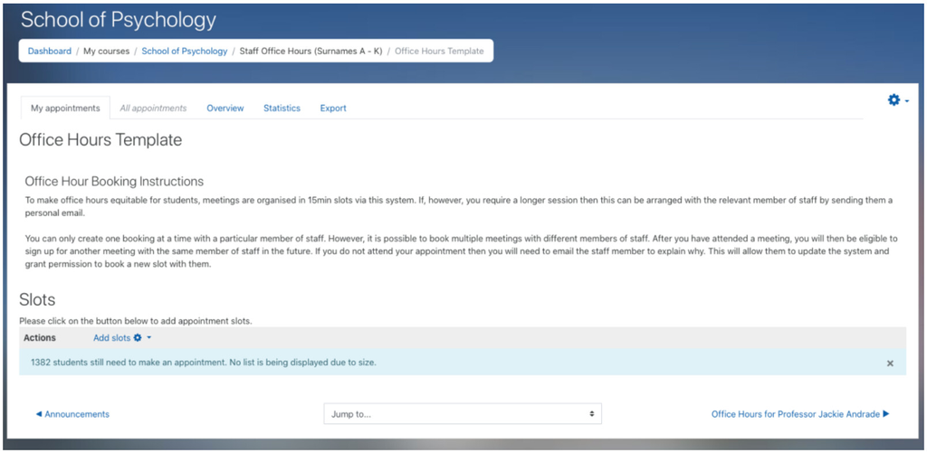

Office Hours Template

The text in the booking instructions is standard text inserted into every scheduler. You modify this text by clicking on the gear icon in the top right corner and selecting edit settings.

You will also see that a very large number of students ‘still need to make an appointment’. Ignore this. Clicking on the cross to the right of this message will dismiss it, but it will reappear next time you access the scheduler.

To add slots, click on ‘Add Slots’ and then select ‘Add repeated slots’ to create multiple sessions. The follow options will appear.

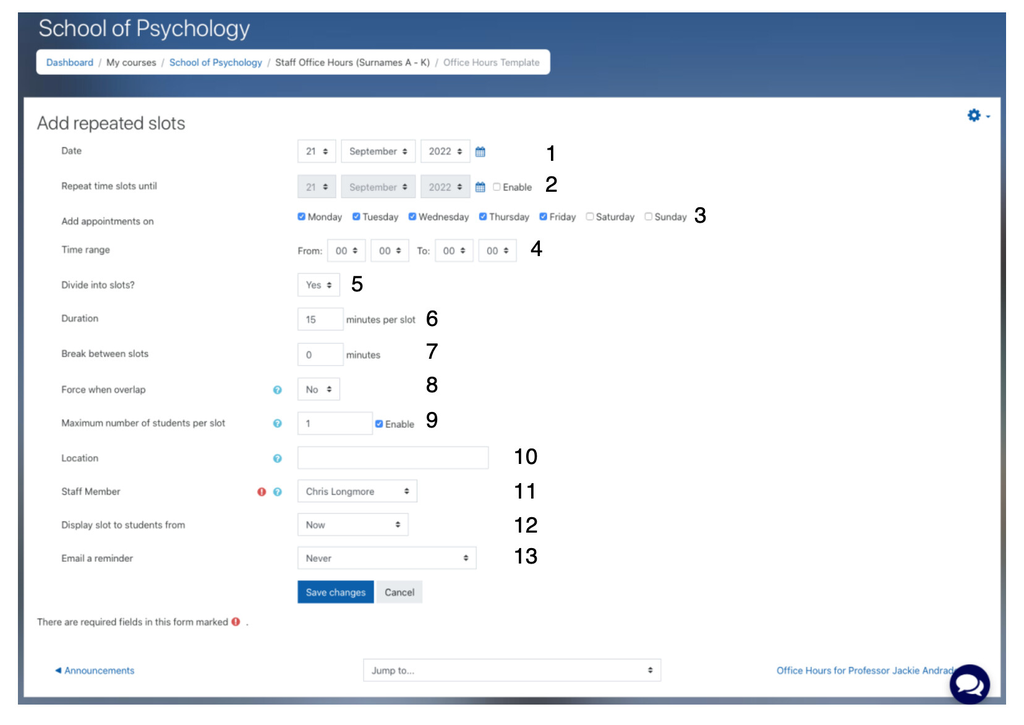

Offie Hours Slot

Use the key below to fill out this form.

Create the slots by clicking on ‘Save changes’. You will be taken back to the list of slots in your scheduler showing the newly create slots.

## 6.4 Worked example

Click enable in 2 and set 2 to 16 December 2022.

In 3, select only Monday.

Set 4 to read: 13 00 and 14 00.

5 – 9 should be on their defaults. Check that they are.

Enter your meeting location in 10 and select your name from 11. Change 13 to ‘On the morning of the appointment’.

Click ‘Save changes’.

# 7 Examination marking

(updated November 2023)

## 7.1 The examination

Most students sit exams in the same main venue. Some with modified assessment provisions (extra time, rest breaks, small rooms) sit exams in other locations. A few more will be completing Alternative Assessment (the same exam, starting at the same time, but in a less formal setting and with flexible timings). At the end of the examinations, all papers are collected and taken to the Examinations Office, where they are collated.

## 7.2 After the examination

The day after the examination, the collated papers are brought to the School of Psychology, or Fiona Trembath collects them (sometimes this can happen later the same day for morning examinations). They are then sorted into question sets for each marker, who is emailed and asked to collect them.

## 7.3 Marking

Exam scripts are marked using the LETTER GRADES F- to A+, with N reserved for answers ‘not worthy of a mark’ where nothing more than the essay title has been written. The mark is written on the front of the script. No other annotations need be made (legally, students can ask to see their marked scripts so bear this in mind). No personal excel files or other records should be made.

## 7.4 Pre-marking moderation

The first three marked scripts for each marker on a question (six if the marker is in their first year of marking for the School) need to be moderated by the Academic setting the question (or the Module Leader). They should be scanned digitally (e.g., using the copier in PSQ B222), renamed with the SRN and Question number, and the PDF files emailed to the moderator.

The moderation needs to be recorded on the Moderation Form, which should be uploaded to the External Examiner folder on the DLE. The scanned scripts that were moderated should also be uploaded.

## 7.5 Mark Entry

Once marking of a question is complete the paper scripts should be returned to Fiona. For online exams, send Fiona an email to say which question has been marked. Fiona and a team of mark entry assistants then enter every SRN and Grade into a CSV file for each question, and download grading sheets from online examinations from the DLE.

## 7.6 Mark Collation

A Markdown script CollatoR.rmd then processes the CSV files. It does the following:

- converts all letter grades to percentages
- checks that all percentage marks match categorical grade values
- flags students who have marks from too many questions
- identifies incorrectly entered SRNs
- lists students with no marks or too few marks
- applies any moderation to any markers’ files (moving grades up or down)
- if multiple mark files per question, run oneway ANOVA to compare files
- report distribution of marks and descriptives for each question
- where necessary, combine marks from different questions into a section mark, and produce statistics
- combine marks from different questions into an overall exam mark, and report statistics
- save CSV files for upload to DLE for each Question, and for overall Examination mark
- produces an HTML (or word, or PDF) document summarising the examination marks, for upload to the External Examiner folder on the DLE

This script is run iteratively, to allow for entry errors to be corrected, and for moderation to be applied, until the Module Leader is satisfied with the final statistics.

## 7.7 After mark collation

The CSV files are uploaded by the Assessments Officer or the Module Leader to the DLE.

When the overall examination mark is released (without notifying students) it will copy the overall exam mark to UnitE. Once the overall mark is in UnitE, it is visible to students via the Portal. Karen Barnett can be notified that marking of this exam is complete.

When the individual Questions are released to students, they will be able to see their individual question marks on the DLE. Students should be emailed before this happens to let them know that the marks will be released.

The report from the CollatoR should be uploaded to the External Examiner folder, along with moderation reports and sample scripts.

Once the External Examiner folder is complete, the Examiner will be asked to scrutinise the assessment.

The module leader will report to the Subject Assessment Board in June on the examination and answer any questions raised by the external examiners.

# 8 Releasing Marks

## 8.1 Have the final marks been uploaded?

If the marks are on the DLE, skip this section.

If you have adjusted the marks and need to upload them, upload the modified grading worksheet. Be sure it is in comma-separated .csv format.

From the Grading Action drop menu, choose “Upload Grading Worksheet” and submit the .csv file with the adjusted marks. Be sure to check the box about overwriting marks.

If you are combining marks from different assignments, you will need to upload them to a ‘hidden assignment’ that has been set up for you. First reveal Identities in each assignment, and the hidden assignment. Then download all the gradesheets. Combine the marks and transfer them to the gradesheet from the hidden assignment. Finally, upload this to the hidden assignment. (You can use the gradebook to combine marks safely within the DLE but you still need to download the combined mark, merge with the hidden assignment, and reupload).

## 8.2 Marks release and upload to UnitE

1. Click the DLE submission link, then view all submissions.
2. At the top drop-down menu (where is says “separate groups”), select “All participants” - this might already be selected. If not already done so: from the Grading Action drop down menu at the top, select “Reveal Student Identities”
3. Scroll to the bottom of the page (command + down arrow). Under Options, be sure the “Assignments per page” is set to “All”. Now scroll back to the top of the page (command + uparrow). Just above where the rows of student records start, on the left, check the box “Select”. This will select every student record.
4. Back at the bottom of the page, from the “With selected…” drop down menu, choose “Set marking workflow state (Release grades and feedback)”
5. Hit Go. (you will be asked to confirm, then continue)
6. On the next page that appears, from the “marking workflow” drop down menu at the bottom, select “Release”
7. Notify students should be set to “Yes” for all assignments that contain submissions and feedback, but “No” for ‘hidden’ combined marks assignments without submissions or feedback.
8. Save Changes

# 9 Research Links

[Psychology Research website](http://www.plymouth.ac.uk/research/psychology) - [School Seminars](http://www.plymouth.ac.uk/research/psychology/seminars) ([DLE](https://dle.plymouth.ac.uk/course/view.php?id=66067&section=4)) - [Gradbook](https://gradbook.plymouth.ac.uk/) - [TechOffice](https://psy.plymouth.ac.uk) - [SONA](https://uopsop.sona-systems.com/) - [Ethics](https://apply-ethicsonlinesystem.plymouth.ac.uk/)

## 9.1 Getting Funding

- [Je-S Research Council system](https://je-s.rcuk.ac.uk/) - Now closed
- [UKRI Funding Service](https://funding-service.ukri.org/signIn)
- Core questions for UKRI-FS
- Resumé for Research and Innovation R4RI [template](https://www.ukri.org/publications/resume-for-research-and-innovation-r4ri-template/) and [Guidance](https://www.ukri.org/apply-for-funding/develop-your-application/resume-for-research-and-innovation-r4ri-guidance/)
- [Support for proposal writing](https://www.plymouth.ac.uk/research/support/funding)
- [Grant application flowchart](https://www.plymouth.ac.uk/research/support/funding/research-funding-flowchart)
- [10 Key Sentences](http://www.parkerderrington.com/key-sentence-skeletons/), [How to win a grant](https://corticalia.wordpress.com/2015/09/01/how-to-write-a-winning-grant-proposal/)
- How to write a [strong NIHR proposal](https://www.nihr.ac.uk/researchers/apply-for-funding/how-to-apply-for-project-funding/make-a-strong-application.htm)
- Applying to ESRC
- [ESRC review process](https://liveplymouthac.sharepoint.com/:b:/r/sites/SchoolofPsychologyStaff/Shared%20Documents/Research/Getting%20funding/ESRC%20Grant%20Assessment%20Process.pdf?web=1)
- [Support available in School](https://liveplymouthac.sharepoint.com/:b:/r/sites/SchoolofPsychologyStaff/Shared%20Documents/General/Old%20SIS%20site/files/Research%20support%20and%20processes%20in%20psychology.pdf?web=1)
- [Successful Application Library](https://www.plymouth.ac.uk/research/support/funding/guidance)
- [BRIC MRI proof-of-concept form](https://liveplymouthac.sharepoint.com/:w:/r/sites/SchoolofPsychologyStaff/Shared%20Documents/General/sis/files/BRIC%20Proof%20of%20concept%20form.docx?d=w2a21fff8032e4818807e9146d3f11d1e&csf=1&web=1&e=Wk4xoE)
- [Risk assessment](https://liveplymouthac.sharepoint.com/sites/u77/DRAFT%20Health%20%20Safety%20Documents/Forms/AllItems.aspx?id=%2Fsites%2Fu77%2FDRAFT%20Health%20%20Safety%20Documents%2FRisk%20Management)
- [Data Management Plans](https://plymouth.libguides.com/researchdatamanagement/dmp)

To access Award Manager, log in to Unit4 via [Corporate Self Service](https://liveplymouthac.sharepoint.com/UsefulLinks/SitePages/Corporate%20self-service%20and%20information.aspx) then select ‘Award Management’ from the options on the left hand side. If it is not there contact the Funding Advisory Service. **Watch this [short video](https://drive.google.com/file/d/1rV9yKYq9pTU-z9FtP9znx89O_uu4pVg3/view?usp=drive_web) to understand how it works.**

## 9.2 Doing Research

- [Ethical review](https://www.plymouth.ac.uk/research/governance/ethical-review), [Application Process](https://liveplymouthac.sharepoint.com/sites/u136/SitePages/Staff%20and%20PhD%20Ethics%20Applications.aspx), [Online System](https://apply-ethicsonlinesystem.plymouth.ac.uk/)
- [OpenSesame](https://osdoc.cogsci.nl/4.0/download/), [tutorials](https://osdoc.cogsci.nl/4.0/tutorials/beginner/) and [JATOS](http://jatos.plymouth.ac.uk/) server
- [JISC Online surveys version 3](https://app.onlinesurveys.jisc.ac.uk/login) and older [version 2](https://admin.onlinesurveys.ac.uk/accounts/login/)
- School [Limesurvey](https://psysurvey.plymouth.ac.uk/) server (called psysurvey) and [Guide on use](https://jon-may.github.io/limesurvey/docs/index.html)
- [Recruiting through Prolific](https://liveplymouthac.sharepoint.com/:w:/r/sites/SchoolofPsychologyStaff/Shared%20Documents/Research/Doing%20research/I%20am%20new%20to%20Prolific.docx?web=1) - [Prolific login](https://app.prolific.co/register/researcher)
- email Pointsadmin and access [points SONA](https://uopsop.sona-systems.com/) or [paid SONA](https://uopsopp.sona-systems.com/)
- [Primo](https://primo.plymouth.ac.uk/), [Scopus](https://plymouth.idm.oclc.org/login?url=http://www.scopus.com) and [Web of Science](http://plymouth.libguides.com/webofscience)
- [Intellectual Property and Data Ownership](https://www.plymouth.ac.uk/research/support/intellectual-property)

### 9.2.1 Impact

- [Ways of getting involved with NICE.docx|attachment](https://liveplymouthac.sharepoint.com/:w:/r/sites/SchoolofPsychologyStaff/Shared%20Documents/Research/Generating%20impact/Ways%20of%20getting%20involved%20with%20NICE.docx?web=1)
- Embedding impact in grant applications [Impact in grants - notes.docx|attachment](https://liveplymouthac.sharepoint.com/:w:/r/sites/SchoolofPsychologyStaff/Shared%20Documents/Research/Generating%20impact/Impact%20in%20grants%20-%20notes%20from%2015%20Jul%202024.docx?web=1) [Impact in grants - Slides 15 Jul 24.pdf|attachment](https://liveplymouthac.sharepoint.com/:b:/r/sites/SchoolofPsychologyStaff/Shared%20Documents/Research/Generating%20impact/Impact%20in%20grants%20-%20Slides%2015%20Jul%2024.pdf?web=1)
- [Impact: What counts?](https://liveplymouthac.sharepoint.com/:w:/r/sites/SchoolofPsychologyStaff/Shared%20Documents/Research/Generating%20impact/Impact%20report%20Feb%202024.docx?web=1) - Panopto of talk by Jackie Andrade, 23/2/2022
- Using social media smartly: [Social Media Cheat Sheets for Academic Engagement.docx|attachment](https://liveplymouthac.sharepoint.com/:w:/r/sites/SchoolofPsychologyStaff/Shared%20Documents/Research/Generating%20impact/Social%20Media%20Cheat%20Sheets%20for%20Academic%20Engagement.docx?web=1) [Maximising impact through social media.docx|attachment](https://liveplymouthac.sharepoint.com/:w:/r/sites/SchoolofPsychologyStaff/Shared%20Documents/Research/Generating%20impact/Maximising%20impact%20through%20social%20media.docx?web=1) (17.2 KB) [Social media Content Guide - Research.pptx|attachment](https://liveplymouthac.sharepoint.com/:p:/r/sites/SchoolofPsychologyStaff/Shared%20Documents/Research/Generating%20impact/Social%20media%20Content%20Guide%20-%20Research.pptx?web=1) (3.3 MB) How to write a blog [Research impact group Apr 19th.docx|attachment](https://liveplymouthac.sharepoint.com/:w:/r/sites/SchoolofPsychologyStaff/Shared%20Documents/Research/Generating%20impact/Research%20impact%20group%20Apr%2019th.docx?web=1) (16.5 KB)
- Testimonials are useful impact evidence, showing how ‘hard’ evidence of impact (health improvement data, sales figures etc) links to your research. Here’s guidance on how to collect [testimonials](https://www.fasttrackimpact.com/post/2018/02/23/getting-testimonials-to-corroborate-the-impact-of-your-research).
- [Fast Track Impact](https://www.fasttrackimpact.com): everything you wanted to know about research impact and how to achieve it
- [People in Research](https://www.peopleinresearch.org) An NIHR website supporting patient and public involvement (PPI) in research
- SoP impact report: [Impact report Feb 2024.docx|attachment](https://liveplymouthac.sharepoint.com/:w:/r/sites/SchoolofPsychologyStaff/Shared%20Documents/Research/Generating%20impact/Impact%20report%20Feb%202024.docx?web=1) (89.8 KB)
- SoP impact strategy: [staff meeting impact slides feb 2024.pptx|attachment](https://liveplymouthac.sharepoint.com/:p:/r/sites/SchoolofPsychologyStaff/Shared%20Documents/Research/Generating%20impact/staff%20meeting%20impact%20slides%20feb%202024.pptx?web=1) (1.8 MB)
- [Video summaries of REF2021 impact case studies from Faculty of Health including Psychology](https://www.plymouth.ac.uk/research/ref2021/health)

### 9.2.2 Open Science

- [Open Science Blog](http://blogs.plymouth.ac.uk/research/2018/06/01/research-data-policy-2018-removing-the-barriers-to-open-data/), [Data Policy](https://www.plymouth.ac.uk/uploads/production/document/path/6/6913/Research_Data_Policy.pdf), [School Open Science Policy](https://liveplymouthac.sharepoint.com/:w:/r/sites/SchoolofPsychologyStaff/Shared%20Documents/Research/Open%20science/School%20of%20Psychology%20open%20science%20strategy%202021.docx?web=1)
- [How to do open science](https://opennessinitiative.org/guidelines-for-authors/)
- [Open publishing](https://plymouth.libguides.com/research/oa) : Library Info
- [Read & Publish](https://plymouth.libguides.com/research/readandpublish) open access with no fees
- [Very Brief Guide to R](https://ajwills72.github.io/rminr/#vbgtr)
- [Zenodo.org](https://zenodo.org/) and [Open Science Framework](https://osf.io/)
- Learning R: [RMinR](https://ajwills72.github.io/rminr/) (Stage 1) and [RMInP](https://benwhalley.github.io/rmip/) (Stage 2)
- [R-Studio Server](https://rstudio.plymouth.ac.uk/)

### 9.2.3 On acceptance

- Add a record to [Pure](https://pure.plymouth.ac.uk/) and
- Upload your [authors’ copy of ms](https://liveplymouthac.sharepoint.com/sites/x103/SitePages/Deposit-your-Outputs.aspx)

## 9.3 Postgraduate Students

- [Doctoral College](https://www.plymouth.ac.uk/doctoralcollege)
- [PhD Competition Criteria](https://liveplymouthac.sharepoint.com/:w:/r/sites/SchoolofPsychologyStaff/Shared%20Documents/Research/Post-Graduate%20Research/SoP%20PGR%20Competition%20Scoring%20Criteria.docx?web=1)
- [Training for supervisors](https://www.plymouth.ac.uk/student-life/your-studies/research-degrees/examiners-chairs-and-supervisors/supervisors) and [examiners](https://www.plymouth.ac.uk/student-life/your-studies/research-degrees/examiners-chairs-and-supervisors/examiners-and-chairs)
- [Gradbook](https://gradbook.plymouth.ac.uk/)
- [Research Degrees Handbook](https://www.plymouth.ac.uk/student-life/your-studies/research-degrees/doctoral-college/research-degrees-handbook)
- [Research Degrees Staff Manua](https://liveplymouthac.sharepoint.com/sites/x75/SitePages/PGR-Staff-Resources.aspx#staff-code-of-practice)l
- [SWDTP pages](https://www.swdtp.ac.uk/)
- School [PhD advert](https://www.plymouth.ac.uk/schools/psychology/phd-studentships) and [application](https://www.plymouth.ac.uk/student-life/your-studies/research-degrees/applicants-and-enquirers)page
- [list of potential internal examiners](https://liveplymouthac-my.sharepoint.com/:x:/g/personal/patricia_kanngiesser_plymouth_ac_uk/EU0NlrgP5KNHg3KRT4dNxlsBZ3ZHZTdaIoEP28V7k6f7GA) with data for Gradbook

## 9.4 Research Groups

- [School Research Site](http://www.plymouth.ac.uk/research/psychology)
- [List of research Groups](https://liveplymouthac.sharepoint.com/:x:/r/sites/SchoolofPsychologyStaff/Shared%20Documents/Research/Research%20groups/List%20of%20research%20groups%201.xlsx?web=1) and [When groups meet](https://liveplymouthac.sharepoint.com/:x:/r/sites/SchoolofPsychologyStaff/Shared%20Documents/Research/Research%20groups/when%20research%20groups%20meet.xlsx?web=1)
- Group websites or Teams channels
  - [BRIC website](https://www.plymouth.ac.uk/research/psychology/brain-research-and-imaging-centre) and [Wiki-handbook](https://brichandbook.readthedocs.io/en/latest/index.html)
  - [Functional Imagery Training](https://www.plymouth.ac.uk/research/psychology/applied-psychology/functional-imagery-training)
  - [Health Lab guides](https://liveplymouthac.sharepoint.com/:f:/s/u325/EjVG6rP9w9tOpfFe5P2zGWsBZ00q0tQ2rXULJy-txxoQww?e=rFl5Wc)
  - [Baby Lab](https://www.psy.plymouth.ac.uk/babylab)
  - [Human-centered AI group (HAIG)](https://teams.microsoft.com/l/channel/19%3Ae8f5b94819e84580964791403fca9f63%40thread.tacv2/HAIG?groupId=137225cb-afa0-45e2-82c4-9463d0501636&tenantId=5437e7eb-83fb-4d1a-bfd3-bb247e061bf1)
  - [Cognition Group](https://teams.microsoft.com/l/channel/19%3A22912710cc6a4b11b25e04de83b98fdf%40thread.tacv2/Cognition%20Group?groupId=137225cb-afa0-45e2-82c4-9463d0501636&tenantId=5437e7eb-83fb-4d1a-bfd3-bb247e061bf1)
  - Environmental Psychology Research Group
  - [Face lab](https://teams.microsoft.com/l/channel/19%3Ab3dffc9eb37f4fcdae35b20a5329eb9f%40thread.tacv2/Face%20Lab?groupId=137225cb-afa0-45e2-82c4-9463d0501636&tenantId=5437e7eb-83fb-4d1a-bfd3-bb247e061bf1)
  - Mental Imagery Research Group
  - Eye Tracking Interest Group

## 9.5 Research projects

- [In the Dancer’s Mind](http://blogs.plymouth.ac.uk/dancersmind/)

# 10 Research Information

This section provides a quick overview of the systems in place to support the research activities of Academic Staff in the School of Psychology. It contains references to the links on the main post, but no actual links. It is structured to match the main page.

## 10.1 School Seminars

There is normally a research seminar every Wednesday afternoon in teaching weeks, to which all staff and students are invited, with tea/coffee/biscuits beforehand. The Seminar Organisor* will periodically ask for suggestions about people to invite, and this is a good way to get a colleague elsewhere to visit so you can discuss research ideas or other collborations. The School will pay for their travel and overnight accommodation, and also an evening meal (for two staff and the speaker).

- To find out who is currently in a management role such as Seminar Organiser or AHoS-Research, consult the Management Roles link.

## 10.2 Funding

The majority of Academic Contracts in the School include Research and the School is keen that everyone should be in a position to obtain external research funding. The Associate Head of School for Research (AHoS-Research)* is responsible for helping you to achieve this, and it will be discussed at your annual Performance and Development Review (PDR) meeting.

The UK Research Councils use a common submission portal, **Je-S,** but **Funder Information** provides links to their main sites. Note that Je-S is soon to be replaced by a new system.

The University has a team to provide **Support for Proposal Writing**, with a **Grant application flowchart** to help you through the process, and there are several links here on strategies to improve the chanes for your proposal, as well as a summary of the **Support available in School.** The Research office host a page whjioch includes access to a **successful applications library**, which is very useful for working out how to best write your proposal.

Not all research requires a large amount of external funding, and often pilot work needs to be done to make applications more likely to succeed. You can ask the School for small amounts of funding to conduct studies, provided that you can give a brief ‘business case’. Depending upon the state of finances, there may be emails about ‘Pump Priming’ schemes or similar from the AHoS-R, with deadlines, or you may be able to apply at any time. It is best to just ask. With the opening of BRIC, some funding is available for **proof-of-concept** studies using the MRI scanner.

The **Award Manager** system within Unit4 should be used throughout the proposal writing, costing, reviewing, approval and submission process, and then once you get your grant to manage the project. You need to contact Funding Advisory to get access to this system, and it then appears in the left hand menu when you access Business World through Corporate Self-Service.

Once you have won funding, you will be supported by the Finance Office. Your project will be given a *‘* *Work Order* **’** code that you will need to quote to get anything bought for you. The code will be two letters and six digits, e.g., RR105183, and may be followed by budget line codes of a dash and three digits e.g.,’-101’. Finance will provide you with summaries of the costs and budgets regularly, but also on request. There is no facility for you to manage the budgets yourself, or to inspect them online. Be aware that costs (especially staff costs) often take several weeks to make it through their systems, so the information you receive reflects some time in the past rather than a current snapshot. Do check the costs carefully as mistakes do happen. **You cannot buy anything** yourself and expect to be reimbused, except for food and accommodation. Ask the School Office or Tech Office to make small purchases online using the School Credit Card, but larger purchases may require authorisation, especially computing equipment. Travel and Accommodation should be booked through Key Travel (see Financial Stuff in Management). When you use KeyTravel, you provide the Word Order code to charge things directly to your project. After your trip, subsistence costs can be reimbursed by making an* Expense Claim* using Unit4, which you will definitely need help to do the first few times. Keep all receipts, scan them, and then upload the scans to Unit4 (beware of file size limits). See the nit4 section at the end of the Management column.

## 10.3 Doing Research

### 10.3.1 Applying for ethics

Before collecting any research data, whether or not you expect it to be published, you need to obtain **ethical approval**. For Staff and Postgraduates, there is an **Online System** to complete which will send your application to the Faculty Ethical Committee. It can take several weeks for scrutiny and changes are often requested, so apply in good time. Note that for any research conducted away from the University, a letter from the host organisation giving permission is required.

### 10.3.2 Getting help running research

You can get Undergraduates to help run your research in four ways: by signing them up each Easter as next year’s Stage 4 or Stage 5 *Dissertation Students*; by taking them on as *Research Apprentices*; by recruiting them as an *Internal Placement Student*; or by employing them for a few weeks during the summer vacation on an *Internship*. Apprentices can be recruited for half a day a week for ten weeks (nominally, this is flexible) by placing an **advert** and then **registering** them. They are usually Stage 1 or 2 students who volunteer in exchange for an insight into research techniques before doing their project, but some Stage 4 or 5 students also volunteer to broaden their experience. You can ask for extra Participation Points as an incentive to take them on (but they do not get any other resoucres). **Summer Employment** can be done through the research assisstance scheme and they can earn £200 for up to ten weeks. Details should be given to you by email towards the end of Semester 2. Placement Students take a whole year out of their course to do work experience with you and are a more serious commitment. You will be treated like an external palcement host. You must advertise, interview, and appoint via the placement office, between January and Easter. The placement runs for 36 weeks between September and June. Places are limited so liaise with the School’s Internal Placements Tutor.

The Library collection and online journals is accessible through **Primo** (and should be , so our access is recorded and journals seen as highly used). We have access to the **Scopus** and **Web of Science** databases. As people did not use Primo, we no longer have subscriber access to APA journals, so you will have to scour Google Scholar for illicitly uploaded PDFs.

#### 10.3.2.1 Summer Internships for students

We can pay students a bursary (as ‘financial assistance’) rather than wages because:

1. The scheme is not internship or employment.
2. The scheme is an enhanced learning opportunity for students who have demonstrated a significant aptitude in subject areas.
3. The learning opportunity allows the student to practise in a live working environment whilst under supervision.
4. The student must produce written results either during or at the termination of the project.
5. The scheme takes place during the vacation period and the maximum attendance will be ten weeks.
6. The £200 weekly payment is as per guidance from the British Psychological Society and is to be paid as financial assistance to enable the student to remain in Plymouth to take part in the scheme.

The payments will be processed through P2P in Finance by completing Request for Payment forms (RFP) – see link below. Information required will be student name, number, bank details and reason for payment - to be presented as **Undergraduate Research Assistance Payment**. These payments will be made at the start and at the end of the scheme rather than weekly.

Important points for potential supervisors, to satisfy the above requirements:

- 1. Students should be paid in two lump sums
- 2. Supervisors and students should agree a set of learning outcomes before the placement begins, to be included in the report…
- 3. They should write a report on their work, to be read and commented on by the supervisor and sent to AHoS for Research at the end of the period of research.
- 4. The scheme is open to students at the end of stage 2, stage 3 if they have been on placement, and stage 4 if they are progressing to stage 5 on the MPsych programme. Students who have completed an undergraduate degree and are progressing straight onto a higher degree (MSc or full-time PhD), with only the academic summer holiday in between, also qualify.
- 5. All students should be made aware that this opportunity is potentially available. We will do this by advertising it as a possible outcome of successful research apprenticeships (JA action).

[Link to the RFP form to use](https://liveplymouthac.sharepoint.com/:x:/r/sites/SchoolofPsychologyStaff/Shared%20Documents/General/sis/files/Payment%20Request%20Form.xlsx?d=w51c9a1805cbe4b5bb2dd1116001b907d&csf=1&web=1&e=5rrIS9) Send to the School Office who will check it is correct before you send to payments.

Now if you want to pay someone for work, so with taxes etc. you will need to raise another type of contract, and then the person to contact about tax, etc is Rachel Edwards

**Compensation and Benefits (Payroll) Advisor**

Talent & Organisational Development|Plymouth University|17a Portland Villas|Drake Circus|Plymouth|PL4 8AA +44 (0)1752 588188 rjedwards@plymouth.ac.uk

### 10.3.3 Designing experiments

The open platform **OpenSesame** has been adopted to support computer based experimentation, and the school has a **JATOS** server to run experiments online (ask Tech Office for an account). For online surveys, the school currently has a paid-for **Qualtrics** aaccount and there is an active user group for it, although future funding is not certain. You can obtain a login from **PsyResources**. Some staff might have *SurveyMonkey* accounts funded by research grants and if you ask around they may share access. The University prefers **JISC-Online Surveys** and you can obtain an account from the IT Support Portal (aka TIS).

### 10.3.4 Recruiting participants

To recruit general public for online studies, we have a **Prolific** account, but funding is required (can be applied for within the school).

See links above for more information on Prolific

We use the **SONA Participation** system to run paid and ‘course-credit’ research within the school. All stage 1 and stage 2 undergraduates have to take part in 11 hours of research participation (15 mins = 0.5 points, 30 mins=1 point or £5, etc), and stage 4 use the points they collect in stage 2 to recruit other students for their dissertations. MSc students are given 40 points; PhD students and Staff can ask for 100 points at the start of each academic year, and further points will be distributed in Semester 2. Points have to be collected/used by a date near the end of Semester 2, so plan your research accordingly. SONA is run by the **pointsadmin** technical officer. You will get emails from pointsadmin when points are available to ask for, but if you have an urgent need, ask anyway.

Paid studies can also be run using SONA, provided you have funds, and participants can receive Amazon Vouchers automatically at a rate of £5 per half hour (minimum £5). To pay people cash or using vouchers, some form filling is required - do not use your own money and attempt to claim it back. We currently have a systen in place to provide digital **Amazon vouchers**, but older forms are available in **Getting Money to pay Participants,** along with cost approval forms for postgraduate studies. Participants receiving benefits shoukld be given a vesion of the **Letter for participants receiving benefits** to show to the JobCentre.

### 10.3.5 Paying participants

Participant payments can be obtained through the following process in the School of Psychology. The school’s standard rate is £10 / hour, £5 / 30 minutes.

If you are using the [Paid Pool SONA system](https://uopsopp.sona-systems.com) then you can send people Amazon vouchers - either pay everyone £5 for 30 minutes (minimum duration for vouchers) or offer a prize draw for shorter studies (e.g., chance to win £25). You can find your participants’ email addresses from the Download Participant list; send these to the tech office with details of the account to pay from.

If you are using Prolific to recruit people online, [they recommend at least £9 / hour](https://researcher-help.prolific.co/hc/en-gb/articles/4407695146002-Prolific-s-payment-principles), so it would be best to use the School’s £10 / hour rate.

- Use these Cash advance and Costings forms (email Fiona.trembath@plymouth.ac.uk for advice on their use)

#### 10.3.5.1 Using vouchers to pay participants

Important: We will only be purchasing vouchers in increments of £5, so: Study length 0 – 30 mins = £5, 31 – 60 mins = £10 …etc…

For prize draw type rewards whole numbers divisible by 5 only please.

##### 10.3.5.1.1 Source of Finance

Are you looking to use the General School Research funds to pay for the vouchers? If yes: Email Caroline Floccia for approval in the first instance. Or are you using bench fees, an individual research grant or another means of finance?

If yes: Make sure you know the work order code for this purchase. If unknown then please contact either the School Office or your project supervisor. Bench fee spending will require an authorised costing form available from the School Office Finally contact the School Technical Manager directly with the work order, number and value of vouchers required.

Note: If you do not have sufficient funds to gather the required number of participants please contact Caroline Floccia as general funds may be available as a top up.

##### 10.3.5.1.2 Study Set Up

Are you using the SONA participation system to recruit?

If yes: Once you have agreement for the purchasing of vouchers, set up your study on the system and add slots if possible then email the Pool Admin Team with the following information: Study Title, voucher value, total fund for the study and date this study will conclude by.

Info: The vouchers will be automatically sent to the participants within 24 hours of the credit for participation being granted.

Or are you recruiting in a bespoke format?

If yes: Email the School Technical Manager directly to request the purchase of vouchers with the following information; Voucher value, total fund and work order code.

Info: The voucher codes will be emailed back to you in a spreadsheet for you to distribute manually as required.

##### 10.3.5.1.3 Any other queries?

Email the School Technical Manager directly.

Participant_Payment_ Cash_ Advance_ Request_ Form_Psychology_2013.docx|attachment Internal Placement costing form.doc|attachment MScMPsych Psychology Project costing form.docx|attachment [Postgrad costing form.doc|attachment](https://liveplymouthac.sharepoint.com/:w:/r/sites/SchoolofPsychologyStaff/Shared%20Documents/General/sis/files/Postgrad%20costing%20form.doc?d=w6a1551f8b8dd4fa88386033681651dcf&csf=1&web=1&e=u5azNo)

- Get these signed off by the relevant supervisor/director of studies and countersigned by programme lead (Masters), postgraduate coordinator (PhD), AHoS-R (staff) as appropriate.
- Give Costings and if necessary Cash Advance forms to Fiona at Link 303. Please email one week in advance for amounts above £500.
- Fiona will then be able to release your funds, which you must sign for and will take a copy to keep on record.
- This will be forwarded to Finance to be reconciled with your Bench fees or relevant budget.
- You must ask participants to sign to say they have received cash payments (not needed for vouchers). Participant payment Receipt form Aug 2022 single.docx|attachment

*When your participants sign, ensure they cannot see the details of other participants, to comply with GDPR. Always keep records of participant signatures for reconciling in a locked cabinet, and at the end of your study return to Fiona Trembath for secure keeping.* Any unspent funds must be returned to Fiona and reconciled against your budget.

#### 10.3.5.2 Other resources

- [Welfare Benefits Jobcentre Letter.docx|attachment](https://liveplymouthac.sharepoint.com/:w:/r/sites/SchoolofPsychologyStaff/Shared%20Documents/Research/Doing%20research/Welfare%20Benefits%20Jobcentre%20Letter.docx?web=1)
- [Prolific account process.docx|attachment](https://liveplymouthac.sharepoint.com/:w:/r/sites/SchoolofPsychologyStaff/Shared%20Documents/General/sis/files/Prolific%20account%20process.docx?d=w6c0059e8b94f4290aab1ebb3025a2277&csf=1&web=1&e=mt9vie)

## 10.4 Research Costings

### 10.4.1 Context and Summary

According to the VC’s report to Senate, the Faculty of Health was responsible for 58% of all new grant awards in the University in 2023/24, totalling £17.7M. This good performance is a credit to everyone involved and represents our growing reputation as a research-intensive organization. As our prowess in grant capture increases, it’s important that we price grants correctly. The paragraphs below are intended to help you do this.

This document makes the standard economic distinction between price (the amount one charges for a service) and cost (the amount it costs to deliver that service). It is important to ensure your grant proposal includes as many of the direct and indirect costs of your project as is consistent with the rules of your chosen funder. If the funder has a funding cap for an application (e.g. a £250K maximum), and you are over it, your first thought should be to reduce the goals of the project (or seek a different funder), not start taking out costs you could have claimed (hereafter *underpricing*). Costs do not disappear just because you decide not to charge them to the funder. Therefore, underpricing requires approval of your Head of School, several weeks before the deadline. You should not expect your Head of School to agree to underpricing unless you can make a compelling case for strategic benefit. Heads of School may (but are not required to) refer applications for underpricing to the Associate Dean for Research. The argument that underpricing makes grant applications more ‘competitive’ (i.e., increases chances of success) is largely specious and in some cases can have the opposite effect, where unrealistically priced grants are rejected on that basis.

### 10.4.2 Pricing advice

Below is some specific advice on pricing grant applications in the Faculty of Health. Further advice is available from the University [Research & Innovation service](https://www.plymouth.ac.uk/research/support/funding/award-manager-launch), for costing contact Fundingadvisoryservice@plymouth.ac.uk and application contentresearchadvice@plymouth.ac.uk. In cases where you are going to be working with University Hospital Trust Plymouth, please also contact the [Joint Clinical Research Office](https://www.plymouth.ac.uk/research/joint-clinical-research-office) at an early stage (jcro@plymouth.ac.uk). If working with other Trusts and you are unsure of their R&D contact, please contact the above teams and our local NIHR RDN Health and Social Care Study Support Service Manager (swp.rrdn@nihr.ac.uk).

### 10.4.3 Investigator time

Price the PI at 20% FTE for a typical grant, reflecting the wide gamut of tasks involved in delivery of funded research, from day-to-day management through to conference dissemination, publication (writing), networking and delivering impact etc. This percentage rises with the complexity of the project up to 40% FTE for very complex (typically multi-site) projects. In cases where you are a local PI on a grant led by another institution, cost the Plymouth PI at 10%, assuming you also include appropriate PDRF / RA support. For larger projects, include appropriate additional administrative support such as a full-time Project Manager or Administrator. More generally, remember that your time as a PI is both limited and expensive. Consider alternatives to raising the PI price above 20% FTE, such as more PDRA time, a project manager or administrator post, technician time, etc.

Co-I’s must make a substantive contribution. Typically, price each Co-I at 10% FTE. If their involvement is unusually large, price at 20%. If there are strong reasons for 10% being too much, price at 5%. If a typical level of commitment has been split across two co-Is working in tandem, split the time (e.g. 2 x co-I at 5% each).

### 10.4.4 Fellowships

If your project involves the PI spending a substantial proportion of their time on primary research rather than management, a Fellowship scheme may be more appropriate. These schemes often include teaching replacement costs – where they do make full and appropriate use of them, which will typically mean the maximum the funder allows. Discuss teaching replacement at an early stage with your Head of School, as it has planning implications.

### 10.4.5 Technical staff

Ensure you are appropriately pricing your use of core technical staff time. To do this, discuss your objectives with core technical staff at an early stage, and determine whether core staff time versus a technician dedicated for your project is more appropriate.

### 10.4.6 Project manager / administrator

Similarly, consider the pricing of project management and administration. Charge these to the funder where they allow this and discuss with the relevant members of staff before doing so. On large projects, many funders expect a project manager to be included in the application.

### 10.4.7 Facilities

The Faculty and University has many facilities whose use is chargeable to grants (e.g. Systems Biology Centre, BRIC, Animal house facility). Make sure you appropriately price use of such facilities - prices often differ for internally vs. externally funded work. Also, talk to those running the facilities to ensure your application is appropriately priced and can be accommodated. Key charged facilities are listed on the [project costing request form](https://liveplymouthac.sharepoint.com/sites/u103/Website%20Documents/Forms/Document%20Set.aspx?id=%2Fsites%2Fu103%2FWebsite%20Documents%2FResearch%20Application%20Process)

### 10.4.8 Impact / PPIE activities

Ensure you appropriately price time for impact activities where appropriate. Similarly, include appropriate pricing of PPIE (Patient and Public Involvement and Engagement). This may include pricing investigator time, but also pricing time for advisors, and stakeholders (see [NIHR guide](https://www.nihr.ac.uk/payment-guidance-researchers-and-professionals)). For larger projects, consider including a specific funded post for such activities. Advice is available on impact, [public](https://www.plymouth.ac.uk/research/public-engagement-at-plymouth) and policy engagement activities.

### 10.4.9 Clinical trials

If doing a clinical trial, contact the Clinical Trials Unit [PenCTU](https://www.plymouth.ac.uk/research/public-policy/engaging-with-policy) at an early stage (penctu@plymouth.ac.uk). They provide expertise in designing, developing, and coordinating clinical trials and other studies. Check with them that you are pricing use of their services correctly in your application.

### 10.4.10 University as ‘sponsor’

If the university is the ‘sponsor’ (basically, legally responsible organization) for a project involving the NHS, price in the time of the University Sponsor team where possible (as it is with e.g. NIHR).

### 10.4.11 NHS costs

NHS organizations have processes by which they can claim (from sources other than the grant funder) some of the additional costs of research being conducted, such as support costs and excess treatment costs. Talk to your NHS partner about this at an early stage, as it’s important they also are able to fully claim allowable costs. If some cases, failure to do this properly can leave the university liable for costs to the NHS. Make sure you are aware of the [SoECAT](https://www.nihr.ac.uk/online-soecat-guidance) process.

### 10.4.12 Materials, consumables, and general costs

Ensure you’ve appropriately costed everything you’ll use, including lab consumables, personal protective equipment, and (where allowable) IT equipment. Cost software licenses, open access publishing costs, specific recruitment costs, participant payments, data storage costs, and the costs relating to the development of intellectual property.

### 10.4.13 Equipment

This usually means things over £10K. You’ll need to follow University procurement processes for these, which are non-trivial in time and extent.

### 10.4.14 Travel and subsistence

Include conferences, along with their fees. Include costs of travelling to meet team members and stake holders etc. at other institutions. Where travel is international, include visa costs (see [Travel and Subsistence policy](https://liveplymouthac.sharepoint.com/sites/U11/SitePages/Travel-and-Subsistence-Policy.aspx)).

### 10.4.15 Subcontracts

Include services that you need but the university does not provide, e.g. transcription, translation. You may need to include estimated costing from suppliers, and this may involve the University’s procurement process.

### 10.4.16 Institutional and external partner contributions

In some cases, a funder requires or expects a direct financial contribution, or contribution in kind, from either the University, or an external partner. Where it is the latter, allow plenty of time for agreeing and documenting external partner contributions. Where it is the former, this is a form of under-costing, and thus requires early discussion with your Head of School (see above). There is a [due diligence](https://liveplymouthac.sharepoint.com/sites/u103/SitePages/Due%20Diligence.aspx) process for working with International collaborators.

## 10.5 Open Science

The School is committed to **Open Science**, and encourages all research to be preregistered, with materials, data and analysis scripts posted online in a persistent repository. The Univeristy maintains an **Open Science Blog,** and a **Data Policy**, and there is also a **School Policy**. There is a guide on **how to do open science**, and links to the **Zenodo.org** and **Open Science Framework**repositories for sharing plans and data.The Doctoral College have provided a very good **Guide to Data Management** (a plan is required for ethical approval)

The School uses **R for statistical analysis,** and support materials are provided, but *SPSS* is also available on managed computers and for download from the IT Work-at-home site (although provision of annual licence updates is routinely late and apparently confidential).

## 10.6 On publication

For the REF we must make all papers accessible online within a short period following acceptance (not publication). There are two steps to follow: 1) add a record to **Symplectic Elements** so that the University knows about your publication and it appears on your staff web page (see entry at end of Management column). 2) Upload a PDF ‘authors’ copy’ of your manuscript to the **University repository PEARL**.

Once a paper is published, Symplectic Elements will find it and either automatically update your manual record with the pubication details, or leave it in a Pending folder for you to ‘Claim’ as yours. It may also find others by similarly named authors who are not you, which you can Reject. If you have followed the guidelines and already created a manual record on acceptance, then you can merge the record of the published paper with your earlier manual one.

## 10.7 REF Information

Our REF submission is in Unit of Assessment 4 (Psychology, Psychiatry and Neuroscience). The School’s REF co-ordinator* will regularly ask you to rate your own papers, and to select a subset of these for consideration for the School’s submission. You may be asked to read and rate colleagues’ papers. It is in all of our interests to publish as many papers as we can that might be seen by REF Panels as 4-star; 3-stars are also useful, nothing else is useful for REF.

Impact Case Studies are also important and although we can only subit a few of these, they take years to build up and must be well evidenced and documented. It is worth collecting all potential evidence from non-HE users of your research just in case you need it in several years time. The University system for doing this is **VW Impact Tracker**, which you can use to capture all sorts of evidence file types. If your research does make an impact, and you are asked to prepare a case study, you will need this information then.

## 10.8 Doctoral College

If you have an MPhil or PhD student, then they will be a member of the **Doctoral College**, who are responsible for administering all research postgraduates.

PhD students have a *Director of Studies* (DoS, their main supervisor) and a Supervisory Team of at least one other academic, who does not have to be in the School. You have to attend **training for supervisors and examiners** before you can supervise a student or be internal examiner for a thesis - everyone is expected to take this training shortly after appointment. Only people who have examined at least two vivas at Plymouth can be an internal examiner without also needing a Chair, so we have a **s** **preadsheet of examining experience** to record it.

**Gradbook** is an online system run by the Doctoral College where you access and record information about your research students. The Doctoral College require you to log regular meetings with your students using Gradbook, and to sign off formal progression through the programme including:

- RDC.1 (Project Plan) after 6 months (Full Time) or 12 months (Part Time)
- RDC.2 (Confirmation of Route to transfer from MPhil to PhD) before 18 months (FT) or 24 months (PT).
- RDC.3 (Examination Arrangements - appointment of examiners), at least four months before submision.

The RDC.1 and RDC.2 need to be reviewed by an Expert Commentator (another academic from within the school). You can choose who, in liaison with the PG Tutor. We usually expect the Expert Commentator to be appointed as Internal Examiner, as they will be familiar with the student’s work. Other schools expressly forbid it.

The viva also needs an *External Examiner* **,** and these need to be approved by a committee, hence the need to complete RDC.3 in good time. The rules about who can be an external are in the **Research Degrees Handbook**. If the Externals has not previously externalled the viva will need a Chair (usually the PG Tutor), as will students who are employed by the University as research staff, who will need to have two Externals and a Chair.

Funding for PhD students is highly competitive but these are the main routes: 1) TARAs - the school employs several *Teaching and Research Associates* (TARAs) on five year 0.7FTE contracts to support workshops and marking and these are required to register for a Part Time PhD with fees waived. There are usually two vacancies a year for these posts. 2) SWDTP - as a member of the ESRC funded **South West Doctoral Training Partnership**, we can apply for full 3-year ESRC studentships. We have a good record of obtaining one a year through this scheme. 3) School/Faculty/University Studentships - depending upon the financial climate, the School tries to offer full-time studentships on terms equivalent to research council studentships each year. The Faculty and the University may also offer such schemes, and you will be emailed about these. We have a standing list of projects on an externally visible **School Phd Advert** web page. You can add your own project here by emailing the PG Tutor. 4) Overseas state funded studetns - you may receive a direct email from an overseas student who says they have funding. Do not just bin these, reply politely and foward them to the PG Tutor, who will do some quality control and then circulate them if they are plausible. When you see one circulated, please do consider whether you could offer the student supervision. We have had several strong students in the past. 5) Students employed by projects - we are allowed to include PhD studentships on ESRC project grant applications; Research Assistants employed on grants can also register for part-time PhDs if the School agrees to waive their fees (the employment usually needs to be for at least three years). 6) Self funded students - these do occur, but students will need to pay registration fees; for example people in employment who want a PhD can enrol as part-time students.

To apply, students will have to complete an online application form that includes a **project proposal.** They should work on this with a prospective supervisor (i.e., you). Applications are shortlisted by a committee of senior academics in the School, and then candidates are invited for interview.

## 10.9 School Research Groups

The school is not organised into formal groups, but staff create overlapping and dynamic groupings that everyone (including visitors, postgraduates, placement students, and often project students) is welcome to join. These usually meet every other week for a discussion group, and should maintain a Discourse post with a schedule of meetings so that everyone knows about them.

Links to research groups

# 11 Management

[School](https://dle.plymouth.ac.uk/course/view.php?id=66067) - [Programme](https://dle.plymouth.ac.uk/course/view.php?id=38727) - [Gradbook](https://gradbook.plymouth.ac.uk/) - [RoomBooking](https://resourcebooker.plymouth.ac.uk/) - [Timetable](https://timetables.plymouth.ac.uk/) - [Panopto](https://plymouth.cloud.panopto.eu/) - [TechOffice](https://psy.plymouth.ac.uk) - [Primo](https://primo.plymouth.ac.uk) - [SONA](https://uopsop.sona-systems.com/)

- [Workload Allocation Model](https://wam.psy.plymouth.ac.uk/admin/login/)
- [Management Roles](https://wam.psy.plymouth.ac.uk/browse/admin-roles/) (who does what)
- Roles and Responsibilities
- [Calendar of School Meetings](https://outlook.office365.com/owa/calendar/54a64921ae844a78aa7ccd9d4b7badc2%40plymouth.ac.uk/04dad8c7933546e9b4f47531d64cca4f439343777348088576/calendar.ics) (ics format)
- Give [Anonymous Feedback](https://www.psy.plymouth.ac.uk/communitybox/)
- How to deal with email
- Weekly [Newsletter archive](https://us14.campaign-archive.com/home/?u=6d2359023df73cc9878607a99&id=91248e037a) and sign-up
- [School GitHub site](https://github.com/PlymouthPsychology)
- [School OneDrive folder](https://liveplymouthac.sharepoint.com/:f:/r/sites/SchoolofPsychologyStaff/Shared%20Documents/General?csf=1&web=1&e=XQtnWw)

## 11.1 [Maps](https://liveplymouthac.sharepoint.com/:f:/r/sites/SchoolofPsychologyStaff/Shared%20Documents/General/Floorplan?csf=1&web=1&e=Ioh0bg) and Rooms

- [PSQ Map](https://liveplymouthac.sharepoint.com/:b:/r/sites/SchoolofPsychologyStaff/Shared%20Documents/General/Floorplan/DLE%20copies/FindMyTutor.pdf?csf=1&web=1&e=SXJEAG) | Link [1](https://www.psy.plymouth.ac.uk/home/Images/LINK1_DETAILED.png) | [2](https://www.psy.plymouth.ac.uk/home/Images/LINK2_DETAILED.png) | [3](https://www.psy.plymouth.ac.uk/home/Images/LINK3_DETAILED.png) |placement area map
- [Phone Directory](https://liveplymouthac.sharepoint.com/:u:/r/sites/SchoolofPsychologyStaff/Shared%20Documents/General/Floorplan/DLE%20copies/phonelist.html?csf=1&web=1&e=opgzkM)
- [Editable Door Labels](https://liveplymouthac.sharepoint.com/:f:/r/sites/SchoolofPsychologyStaff/Shared%20Documents/General/Floorplan/Door%20Signs%20and%20Placement%20Area?csf=1&web=1&e=iNx0nM)
- Key Card Access form
- [Psychology Room and Equipment Bookings](http://orb.plymouth.ac.uk/psy)

## 11.2 Programme Management

- Programme Specifications and Module Records
- [Student Voice System (module evaluation)](https://liveplymouthac.sharepoint.com/sites/u279/studentadministration/Student%20Voice/Forms/AllItems.aspx?viewpath=/sites/u279/studentadministration/Student%20Voice/Forms/AllItems.aspx)
- Email M/M tutors: Psy+HB, Psy+Soc, Psy+CCJS
- [PsySoc](https://www.upsu.com/societies/psysoc)
- [Academic regulations](https://www.plymouth.ac.uk/student-life/your-studies/essential-information/regulations)
- [Guide for Module Leaders|attachment](https://liveplymouthac.sharepoint.com/:w:/r/sites/SchoolofPsychologyStaff/Shared%20Documents/General/sis/files/FoB_Guide_for_Module_Leaders%5B1%5D.docx?d=w1753ead9a1c648529c0260943de07a24&csf=1&web=1&e=Lr3ZCq) (from FoB)

## 11.3 Outside the School

- [Essential University Links](https://liveplymouthac.sharepoint.com/UsefulLinks/SitePages/Home.aspx)
- [Health & Safety](https://liveplymouthac.sharepoint.com/sites/u77/SitePages/Site%20Home.aspx) and [Incident Reporting Form](https://liveplymouthac.sharepoint.com/sites/X13/SitePages/Incident-Reporting.aspx)
- [Report Abuse - Bullying, Harassment, Racism](https://www.plymouth.ac.uk/student-life/services/student-services/speak-up)
- Library[Psychology Support Guide](https://plymouth.libguides.com/psychology)
- [Online Training](https://plymouth.learnupon.com/) and [GoodPractice](https://app.goodpractice.net/#/plymouth-uni/s/480f5100)
- [Faculty of HHS Forms and templates](https://liveplymouthac.sharepoint.com/sites/officialdocumentcentre/Templates%20and%20forms)
- [School Athena Swan site](https://liveplymouthac.sharepoint.com/sites/u379) (committee only)
- Faculty [Equality site](https://www.plymouth.ac.uk/about-us/university-structure/faculties/health/supporting-equality-within-the-faculty-of-health) and [Sharepoint](https://liveplymouthac.sharepoint.com/sites/u377/SitePages/FoH%20EDI%20Homepage.aspx)

## 11.4 [Human resources](https://liveplymouthac.sharepoint.com/sites/u114/SitePages/Site%20Home.aspx) (click for page)

- PDR
- [Appointing people](https://liveplymouthac.sharepoint.com/sites/u114/SitePages/Recruitment.aspx)
- [current vacancies](https://liveplymouthac.sharepoint.com/sites/u114/SitePages/Job%20Vacancies.aspx)
- [Promotion](https://liveplymouthac.sharepoint.com/sites/u114/SitePages/Academic%20Promotions%20Career%20Pathways.aspx)
- [Annual Leave and Public Holiday details](https://liveplymouthac.sharepoint.com/sites/u114/SitePages/Annual-Leave.aspx)
- [Employee Self Service](https://hrservices.plymouth.ac.uk/tlive_ess/ess/#/) (Payslips, P60s!)
- [Cyclescheme](https://liveplymouthac.sharepoint.com/sites/u114/SitePages/Cycle%20to%20Work%20Scheme.aspx?CT=1591086737955&OR=OWA-NT&CID=c49515e6-ed5a-42be-0835-986cbafb8a22) - get a tax free bike

## 11.5 [IT Web pages](https://www.plymouth.ac.uk/about-us/university-structure/service-areas/it-services) (TIS)

- phone support: 01752 588 588
- [IT and Estates Support Portal](https://itselfservice.plymouth.ac.uk/)
- [Work at home software](https://workathome.plymouth.ac.uk/)
- [Edit your staff page on the Website](http://www.plymouth.ac.uk/admin)
- [Digital Skills training](https://www.plymouth.ac.uk/services/digital-skills)

## 11.6 Finance

- [Key Travel](https://www.keytravel.com/uk/log-in) for Trains, Flights and Hotels
- [How to submit an expenses claim](https://liveplymouthac.sharepoint.com/sites/u9/Training%20Page/Unit%204%20User%20Guide%20-%20How%20to%20Submit%20a%20Web%20Expense%20Claim.pdf#search=how%20to%20submit%20expense%20claims)
- [Access Unit4](https://ubw.unit4cloud.com/uk_uop_prod_web/Default.aspx)
- [Payment Request Form](https://liveplymouthac.sharepoint.com/:x:/r/sites/officialdocumentcentre/Templates%20and%20Forms/Payment%20Request%20Form.xlsx?d=w9ad9bbaa0fdd41a78e5985b2a298d4d9&csf=1&web=1&e=6PdAXU) (Excel Online)

## 11.7 Printing and Photography

- [DPC webpages](https://www.plymouth.ac.uk/about-us/university-structure/service-areas/marketing-and-communications/design-print-and-photography)
- [University Image archive](https://plymouth.fotoware.cloud/fotoweb/archives/5000-Image-Library/?q=psychology) and [photoshoot form](https://www.plymouth.ac.uk/uploads/production/document/path/6/6839/photo_request_2016.pdf)
- [School Image Archive](https://liveplymouthac-my.sharepoint.com/:f:/g/personal/jon_may_plymouth_ac_uk/EoKLfBdo2F9NvbkKLZeUBlsBdaa6wwL0HtspRf8sbCwhVQ?e=5pNPOp) and [Logo](https://liveplymouthac-my.sharepoint.com/:f:/r/personal/jon_may_plymouth_ac_uk/Documents/Plymouth/School%20Information%20Site/Logo?csf=1&web=1&e=RfJPQc)
- [Printing Posters](https://www.plymouth.ac.uk/student-life/your-studies/library/library-printing-and-multimedia-services)

# 12 Management Information

This section presents an overview of the way that the School of Psychology is managed, along with key administrative resources. It follows the structure of the main page, and contains no links itself. Well, just the one.

## 12.1 How to Deal with Email

This guidance was created to improve staff wellbeing, and make our daily experience less stressful. You may not believe it, [but it works](http://timharford.com/2013/09/3180/). **Important** - it is a University rule that all emails from students should receive a response within **two** working days (i.e., a message received at 5pm on Friday should be replied to before 5pm on Tuesday). An autoreply counts, provided it specifies when you will be able to respond and provides an alternative contact for urgent issues. An autoreply should be set up for any working day when you are not on campus.

## 12.2 Discourse

This is where you are now - a website where everyone can post or search for questions and answers. This is visible by anyone with an account for it, so can be used to post FAQs to common student questions, and help colleagues with common issues. It has a very accurate Search tool, unlike the University web pages. Use the **join** link to ask for access, and **access** to go to the home page.

## 12.3 Management Roles

The School has a Head of School (HoS), a Deputy Head of School (DHoS) and three Associate Heads (AHoS) for Research, Teaching and Learning, and Student Experience. Together these five people form the School Management Group (SMG) and meet each week to run the School. Every other academic will be assigned one or more management roles.

The person currently responsible for each of these roles can be found by following the **Management Roles** link (the heading) which takes you into the Workload Allocation Model (see below). Use your browser’s Find or Search function to look for a word that you are interested in (e.g. ‘apprentice’). Don’t use the Search at the upper right as this looks in the whole WAM site rather than the page.

To find out which Management Role has responsibility for a given task or area, consult the **Roles** (text) document or the **Responsibilities** (diagram).

Management Roles are usually reshuffled each academic session, so if there is a role you would be interested in taking on, tell the HoS.

## 12.4 Maps

There are over a hundred people in the School, with Academic Offices being on the second floor of the Portland Square (PSQ) building (in blocks A and B) and Research Offices being in Link Building (Floors 1 to 3). A CSV file (roomsdata.csv) of who is where is used to generate a **PSQ map**, a **Link Map** and a **phone directory**. These files are created automatically by an R script which can be run by Jon May whenever the DHoS updates the file. Links to the maps are posted to the DLE, so that students can always access the current version. The files are in a shared folder called Floorplan, which also includes a Door_Signs file for the PSQ nameplates. You can access this powerpoint file to edit and print out your own doorplate from the link **Editable Door Labels.** Doors for rooms that you are allowed into can be opened using your staff card, aka ‘Key Card’. Normally these include the main doors to PSQ, your own office, the photocopier/printer opposite the School Office (B222), and the PSQ second floor kitchen. If you need additional rooms added, or need access to different buildings, then you can complete the online **Key Card Acess** forms and somehow your card is updated.

## 12.5 Shared Documents and Data

**Workload Allocation Model -** Key to the school’s management is the **Workload Allocation Model,** or WAM, a database containing all allocated teaching and management roles, each of which has an allowance of time allocated to it. These allowances have been determined as reasonable by the HoS, and if your role takes up more time, then consider the way you are doing it or what you have taken on within the role. If you are still spending too much time on a role, then discuss it with the HoS in case the role needs to be subdivided or shared. An allocation of time for Research activity is also made on retrospective performance (grants managed, papers published). The WAM allows you and the HoS to ensure that individual staff are not overburdened, and that the workload of the school is distributed fairly between staff, with early career staff, newly recruited staff, and staff returning from maternity leave being given lighter workloads. The aim of the WAM is not to account for every single hour, as not all tasks can be fully accounted for in any workload model. A reasonable target would be for 80% of your time to be modelled. Do not let anyone tell you that you should be at 100%; remind them that it cannot and should not include every task.

When you access the WAM, the overview page lists forthcoming tutorials, modules you are teaching on, upcoming Assessments and Marking duties, and a summary of your allocated workload as a percentage of 1650 hours (7.5 hrs a day for 220 days a year). If you click *Your Allocation* the tasks contributing to your allocation are listed (in case of errors, contact Ben Whalley). The *Comparison*plot shows how your workload profile compares to other staff.

**NSS/SPQ -** Each year the government commissions MORI to survey final year students in the National Student Survey or NSS. In past years, the University also ran the same questions on Stage 1 and Stage 2 students as a Student Perception Questionnaire (SPQ). Scores on the NSS are used in league tables and the Teaching Excellence Framework (TEF), so it is imoprtant that we score well on them. All past data, from every University and Course, is kept in the **NSS/SPQ** folder, along with R scripts to generate visualisations. The School used to run its own module evaluation and lecturer evaluation at the end of each semester, and the results from previous recent years can be found in the **Student Evaluation archive**. From 2020-21, this has been centralised and now a subset of NSS items is asked for each module (there is no lecturer evaluation).

**Annual Leave and absence policy -** All staff should take their contractual allowance of leave, but should do so with permission from the HoS. To request leave, email the school office so that they can record it. If you do not take your leave in a calendar year, you can roll over a small number of days to the following year. It is important that leave is recorded, so that in emergencies we know which staff are available, and how to contact staff who are unavailable. Recording your leave helps the school support your wellbeing. It is sometimes more necessary or more productive to work away from campus, whether at home or at other locations (for conferences, external examining, meetings, etc) but staff should notify the school office on days when they are working away from campus for any reason. It is important to be accessible to students during teaching weeks, so working away from campus should be limited to a day a week on average. The HoS has the right to ask you not to work off campus. The School’s **Absence Policy** gives more detail about all of this, and Human Resources have a page with the contractual details (see below). Note that we do not use the centralised Leave system you may find on Employee Self Service (see below), as it does not meet the school’s needs.

A School newsletter is emailed out to all staff and students each teaching week (on Sunday at 2pm). The **Newsletter archive** holds back copies and a link to add names to the mailing list.

If you are familiar with GitHub, you can join the **School GitHub site** to share data and code for specific school projects, or to see the code that people have written to do a variety of things.

## 12.6 Programme Management

The programmes and modules we offer have been through a rigorous quality assurance process, and the documents approved as part of this are kept here. In 2018-19 we began a three year roll-out of a new programme, so these documents are relatively up to date. The program **specifications** define the content and structure of each programme, and each module is defined by its Definitive Module Record (**DMR**). All modules have a code with letters that identify the School and a three digit code indicating the Level of delivery, e.g., PSYC411. Our modules all begin PSYC, and Stage 1 is Level 4, Stage 2 is Level 5, Stage 4 is Level 6, and Masters are Level 7. The Doctorate in Clinical Psychology modules are all CPSY6xx. Revisions are named using an additional digit after a dot (e.g., “PSYC416.3” indicates the third revision).

The DMR has two parts: Part A defines what must be delivered, while part B is descriptive and can be deviated from. Part A includes the Learning Objectives and modes of assessment, including the weightings of examination, coursework and practical components and any pass/fail components. These cannot be varied without approval. The structure of assessment within these components can be varied For example, a module might be 50% Examination and 50% Coursework, but the Module Leader can decide how to sructure the exam(s), and whether the coursework consists of two or three pieces of work (elements), and what each of these ‘elements’ relative weightings are. This structure needs to be communicated to Faculty Administrator, so that the Student Records can be updated to hold the marks for each Element.

If a module leader wants to change anything in part A, they need to request **Minor Changes**, by Late October of the previous session (i.e., if you need to respond to student feedback, you cannot do so the following session, but only the session after that). The **Major Change form** is also provided but you will only want to use that if you have been asked to by the programme lead. The **Quality Assurance Process** pages describe how all this works, though the forms there are out of date and the ones linked here should be used instead.

**Email M/M tutors** If your tutees are taking one of our Majors courses, then two of their modules will be run by a different school. if your tutees raise any concerns about these modules you can contact the person in the other school who is responsible for our students (who we call Majors, as they Major in Psychology, but they will call Minors, hence Major/Minor or M/M). The links for the three programs are given in this section. These students may want to change to a single honours course (often to Psychology, but sometimes the other way). You should discuss this with our Senior Tutor and the relevant M/M tutor.

**Student reps and PsySoc** - The Student Union trains students from each Stage of each programme to be Student Representatives on the School’s Teaching and Learning Committee, and they play a vital role in the running of the school. They are chosen by the student body in the Autumn Semester and serve for a year. There is also an overall Course Representative for each programme. Psychology Students run the **PsySoc** student society which puts on a range of social and educational acitivities for its members.

## 12.7 Policies and Procedures

**Academic regulations** links to the formal regulations covering every eventuality, and also to a wide range of other policy documents. The **Module Leader Guide** was written by a Faculty that no longer exists and is a little out of date, but is still a handy reference to the large number of things a ML has to do. We plan to produce a school version based upon it. **Teaching Responsibilities** details the teaching responsibilties of seventeen different administrative roles, from Deputy Vice Chancellor to Academic Liaison Person, without mentioning Academic Staff who actually deliver the teaching. **Extenuating Circumstances** regulations are here as well as in the Student Support section (above).

## 12.8 Essential University Links

The title links to a page on the portal that is a gateway to a number of official sites within Sharepoint. A few key areas are listed below the title.

**Health & Safety and Incident Reporting Form** - the first link will take you to a site with a varied collection of information about safe working pracrices. If you don’t follow these, you may need to use the second link. Do think about using the second link if there are any accidents or injuries, or near misses, because even if no immediate action is needed knowing that something bad happened helps the University avoid something worse happening in future.

**Online Training and GoodPractice** are links to a site where internal training courses are accessed and your history of doing them can be found. SOMe of these need to be done once, others periodically to keep your awareness up to date (fire training, etc). Good Practice has some helpful information for new staff.

**Psychology Room and Equipment Bookings** links to an online system for finding our when rooms in Link are available to be booked for research activities or meetings (these are not within the University Room Booking system), and bits of useful kit.

If you need to book a room for a non-timetabled event, such as a tutorial or project group meeting, then use the Uni **Resource Booking** system. You can find out the capacities of all of the rooms form Timetabling site’s **Room Capacities** document (a PDF, sadly).

**Faculty of HHS Forms and templates** includes digital version of lots of forms, incuding **external staff expense claim forms** for visitors and speakers to use (probably the only useful one here).

The **School Athena Swan committee** have a restricted site for their own use, which is linked here for their convenience.

## 12.9 Human resources

The title links to a page maintained by HR, with lots of organistion level infrmstion, guifane and rules. Key ones are linked below.

**PDR (Personal Development and Review)** We have two PDR meetings each year, a main one at the start of each session and a six-month follow-up. The page linked here explains the process and links to the forms that you need to complete.

**Appointing people** If you ever need to appoint an RA you eill need to use this site to nvigate the formal process, from telling HR that there is a vacancy, through advertising and recruiting to appointing them. Before you can interview anyone you need to have completed three online courses (see above - Diversity in the Workplace, Unconscious Bias, Recruitment and selection for panel members) and attend a training session ‘Interviewing with Confidence - for Interview Panellists’. There is also ‘Recruitment and Selection for Chairs’ which you need to attend to Chair a panel. Email staff.development@plymouth.ac.uk to ask when the next events are. All staff are expected to be able to Chair their own appointment panels and to sit on other staff’s panels, so everyone does need to do these two courses sooner rather than later.

**Current vacancies** links to the job vacancies currently available should you wish to help other people move here. **Promotion** - the official account of the promotion process, criteria, and forms. **Annual Leave and Public Holiday details** - the official details. **Employee Self Service** - is where you will find your payslips, P60s, and similar HR details including the forms you need to fill in to say who you are (Under Personal in the top menu bar). You can also see which courses you have attended and book new ones via ‘Learning and Development’.

**Cyclescheme** - get a tax free bike. The University is part of this national scheme, which lets you buy a bike worth up to £3000 by monthly deductions from your salary, before Income Tax and National Insurance are deducted, saving you a substantial amount - especially if you are in a higher rate tax band.

## 12.10 IT WebPages (TIS)

IT support is provided by Technology & Information Services or TIS. The University provides a ‘fleet’ machine with managed software for all staff. This is usually a PC Laptop, and is renewed every few years. If you prefer you can ask for a Mac, which also comes with a managed system and pre-installed software. Mac support is outsourced to Amsys, based in Endsleigh Terrace. If you have special requirements, e.g., for display or standing desk, then you should raise it with the Head of School.

You can phone support on the number provided.

To report a problem with anything, you can log into the **IT Support Portal** and raise ‘an issue’, which will be logged and dealt with over the next few days. This is not useful for emergencies, but does get problems logged and counted, which is good if they keep hapenning. Log in with your short user name, not your email address.

**Work at home software** gives access to a range of licensed software that you can download to use on personal or research machines. License codes are not always up to date, especially for SPSS.

**Edit your staff page on the Website** You should keep this up to date as far as possible, and upload a high resolution head-and-shoulders image of yourself. YOu do not need to keep adding publications to it if you tick the ‘Show Elements publications’ box, as this will automaticlaly display any papers you have ‘accepted’ as yours on that system. This is recommended most strongly.

## 12.11 Financial Stuff

- **Key Travel** for Trains, Flights and Hotels. If travelling on University business, then use this site to book all travel, and if possible accommodation. This allows the University to ay for it directly and avoids the need for you to claim it back. If you cannot access the system you may need to be registered for it - ask the School Office how this is currently done. You will also need to know a ‘work order’ code to bill the costs against.
- **Unit4 and External Expense Claims form** If you eat anything, need to claim car travel, or any other expenses then you need to detail them on this system. You will need to scan or photo each receipt and upload it to accompany your claim, but note that there is a filesize limit so you will certainly need to post-process the photo to downsize it. The OneDrive phone app helps here, as it automatically downsizes images it takes and saves them directly to the top level of your OneDrive account, where they can easily be found to upload into Unit4. This means you can snap the receipt as soon as you get it, name it with event and amount, and find it later. The Unit4 system is so arcane it is not worth trying to explain, so seek help from the School Office, but there is a word document that tries to guide you through it.

## 12.12 Printing and Photography

- **DPC webpages** is the front page for the Document Production Centre on Kirby Terrace. This is the Universities professional design and print service which is very useful if you need a brochure or project report or large number of copies of something printed. They are very good, and can produce things requested on a specific order form with costs transferred internally, but are not the fastest option.
- **University Image archive** holds high resolution professional images taken around the University by the photography team from DPC. These are used in print and web and you can search for e.g., Psychology returned 683 results. Login with your SHORT username (not email address). The first time you use it you will be asked to download and install FotoWeb software. This is not entirely necessary, but helps. To book the University photgraphers (Alan and Lloyd) fill in their **booking form**. They want you to have clear ideas of what you want and what you want it for.
- **School Image Archive and Logos** This is a folder of images and graphics about the school that stopped being maintained in 2018. There are many useful things here including staff photois, some stock images we bought licenses for, and University and School logos and Letterheads.
- **Printing Posters** is easily done in the Library. Create a PDF file and save it in OneDrive, ask the School Office to add print credits to your staff card (form filling required), then visit the Library and ask for help there.

# 13 Leave and absence policies

- leave runs from 1 Aug each year
- you can carry 4 days over
- report sickness to the school office from the first day
- request leave via the school office who keep records of it

## 13.1 University documents/policies

All the relevant policies and guidance on leave are currently here:

https://liveplymouthac.sharepoint.com/sites/u114/SitePages/Annual-Leave.aspx

Section 10 of the employment contract also has specifics:

https://liveplymouthac.sharepoint.com/sites/u114/HR%20portal%20documents/Contracts/Core_Terms_and_Conditions.pdf

## 13.2 School leave and absence reporting procedure

This leave and absence procedure is intended to ensure that all staff are able to make full use of their leave entitlement, and to work efficiently and flexibly off-campus, while maintaining effective delivery of teaching and administrative duties within their contracted time. It is intended to be read in conjunction with the [University’s core terms and conditions of work](https://liveplymouthac.sharepoint.com/sites/u114/SitePages/Employee%20Contracts,%20Terms%20and%20Conditions.aspx), and the [sickness absence reporting policies](https://intranet.plymouth.ac.uk/perdev/sicknessabsence/intranet.htm)

### 13.2.1 The key issues from these University policies that are relevant here are:

- Academic staff are entitled to 35 days leave per year (pro rata for fractional contracts). Public holidays (eight days) are in addition to your leave entitlement, giving a total of 43 days leave, plus any period of University closure at Christmas.
- Up to a maximum of 4 days leave may be carried forward each year. Any additional unused leave will be lost, unless exceptionally agreed by the Head of School.
- Up to 6 weeks leave in a single block is allowable, outside of core teaching and assessment time.
- The timing of leave is subject to the agreement of the Head of School / manager and is subject to the organisational requirements of the University.
- Staff should give reasonable notice of holiday requests. Whilst every endeavour will be made to co-operate with staff in fixing the dates, agreement rests at the ultimate discretion of the University.
- Wherever possible, detailed holiday schedules should be made as soon as reasonably practicable after the beginning of each academic year (August 1st). In determining holiday schemes, special regard will be given to lecturers with family responsibilities and those who wish to attend conferences or courses that are held in normal holiday periods. Conferences and courses will not count against holiday entitlement.
- Staff have a responsibility to notify the University of all periods of absence through ill health, starting from the first day of absence.

The purpose of having a School procedure is to ensure that we collectively have the necessary staff working to cover our key obligations in teaching (including the student experience), assessment, research and administration (including recruitment and marketing) as they arise through the year. We also need to meet the requirements of the University as an employer, which has a duty of care towards its employees. With this aim in mind, we want a process that is reasonable and appropriate, and which does not create an unnecessary administrative burden.

## 13.3 School Procedure for Absence Reporting

All periods of absence from the University during contracted hours (leave, working off campus, sickness) will be notified by using the appropriate online system or by contacting the School office, in advance in the case of leave and working off-campus.

All periods of absence from the University during contracted hours will be explained in an out-of-office Outlook message that is consistent with the notification given to the office, and suitable for receipt by students, other University staff, and external recipients. The message should specify the period of absence wherever possible, and offer an alternate contact (e.g. for student enquiries).

All periods of absence from the University during contracted hours should comply with relevant University policies.

## 13.4 Sickness absence

The School should be notified of all periods of absence due to ill health, in line with University policy. This can be done by emailing or phoning the school office on your first day of sickness, by your normal start time. Staff should inform the office why you are away, how long you are likely to be off, and provide the details of any scheduled teaching or meetings that may need to be cancelled or rearranged.

You will need to complete a self-certificate when you return to work to cover the first week of absence, and a statement of fitness work to work (fit note) from your GP when you absence is more than 7 consecutive days, including the weekend.

## 13.5 Annual leave

- All academic staff should notify the School office of requests for periods of leave as soon as possible during the academic year, ideally shortly after the release of the final timetable for each semester.
- Requests in line with University policy will be approved by the Head of School at the earliest opportunity, unless there is a compelling organisational reason to withhold approval. If approval is withheld, the Head of School will discuss the request with the staff member.
- Periods of three or more day’s annual leave should be requested at least 2 weeks in advance. Periods of 1 day per week during the teaching and assessment period, and 2 days per week at other times, should be requested at least two working days in advance.
- Where leave spans two academic years (July – August) it should be requested prior to the start of the leave in the earlier of the two years.
- Periods of leave during teaching and assessment time are possible but may not be approved if they conflict with teaching, administrative or research commitments. Individuals wishing to apply to take leave during teaching and assessment time should discuss the case with the Head of School in the first instance.
- Changes to previously agreed periods of leave will require re-approval as described above.

## 13.6 Working away from the University (including working at home).

The School encourages flexible working practices and recognises the value of working off campus, at collaborating institutions, and at home, but does have a responsibility to staff, students and the University to know where staff are working at all times. For insurance purposes, all work conducted off campus needs to be recorded using the appropriate University systems.

Requests for longer periods of working away from the university will normally be granted (e.g. a week spent marking exam scripts at home is likely to be approved) unless there are compelling organisational reasons to withhold approval.

Staff planning to work away from the University for an extended period of time during contracted hours (i.e. more than 1 day in a week during teaching and assessment time, or more than 2 days in a week outside teaching and assessment time) should seek prior approval from the Head of School at least 2 weeks in advance of the absence. The approval request should specify the period away, the nature and location of the work planned while away, and the steps taken to mitigate the effects of the planned period away.

Staff planning to work away from the University for short periods during contracted hours (1 day a week during teaching and assessment time or 2 days a week outside teaching and assessment time) do not need prior approval, but are required to give prior notification to the School office. This notification should confirm that the absence will not negatively impact upon the working of the School.

Because working away from the University constitutes work, you should provide contact details for your period of absence, and should respond to reasonable work requests, including responding to email requests within two working days, unless agreed in advance by the Head of School.

## 13.7 Part-time working (fractional contract) and non-contracted time

The procedures above apply to working hours within your University contract. For those staff on fractional appointments (i.e. less than full-time) there is an additional requirement that the School is aware when people are working for the School, and when they are not. While the School is willing to adopt a flexible approach to the pattern of work at different times in the year, the organisational requirements of the School need to be met.

The expectation will be that the fractional contract will apply equally to every working week, unless agreed in advance by the Head of School.

Staff on fractional contracts wishing to constrain their working pattern (e.g. to specific days, or specific hours in the week), or wishing to distribute their workload differently across different parts of the year should seek the approval of the Head of School prior to the start of the Academic year in which it will apply, using the [University’s Flexible working procedure](https://documents.plymouth.ac.uk/uop/documents/Personnel%20and%20Development/Pay%20and%20hours%20of%20work/Flexible%20working%20procedure.doc)

Staff on fractional contracts without specific constraints should notify the School of the periods during the working week when they are working for the University, and the periods when they are not, at least 2 weeks in advance.

# 14 Definitive Module Records (DMRs)

Definitive module records (DMRs) are the document used by the University Quality team to track module learning outcomes, assessments and other features.

They are the documents which are validated as part of a programme approval process.

Part A of the module record is therefore fixed, and to change it module leaders need to submit a request for minor changes to a module.

However Part B can (and should) be updated by module leaders each year to reflect new readings etc.

## 14.1 Finding DMRs

You can find current versions of PSYC DMRs here.from around file 880 onwards.

These are the documents which are validated as part of a programme approval process.

## 14.2 Changing a DMR

Part A of the module record is therefore fixed, and to change it module leaders need to submit a request for minor changes to a module.

However Part B can (and should) be updated by module leaders each year to reflect new readings etc.

To change part A, module leaders need to submit a request for **minor changes** to a module using the forms below.

- FoH minor Change form for 2024-25 Implementation updated March 2024.docx|attachment

In order to propose changes to programmes and/or modules for implementation, the form must be submitted along with a track-changed version of the module record. This form should be used for changes to Section A and/or B of module records. If the only change is to a Module/Programme lead please email Health-Quality@plymouth.ac.uk with the change.

The required documentation must be scrutinised by the following prior to submission to the relevant Associate Head Teaching and Learning (AHT&L):

- External Examiner (comment required from EE, unless changes are to Part B of the Module Record only)
- Programme Lead
- Members of the relevant Programme Committee

Following scrutiny, please submit the documentation to your AHT&L for sign off before sending into Health-Quality@plymouth.ac.uk.

### 14.2.1 Changes to assessment

If you are just making changes to the assessment that does not affect the weightings or number of components or elements (e.g., changing an exam from 4 to 3 questions, or into two sections; or changing the nature of a piece of coursework) then you do not need to submit a form.

If you want to split a coursework component into two pieces of work, or combine two pieces or make them ‘either-or’ then you DO need to submit a form.

### 14.2.2 Larger changes

More substantial changes to modules should be documented in a request for major changes.

- Major Change form (as of Jan 2024 so check it’s up to date)|attachment

Contact the University quality team for the latest form (or [possibly find later ones here](https://liveplymouthac.sharepoint.com/sites/u414/SitePages/Site%20Home.aspx) )

# 15 Honorary and Visiting Staff

Please see the [HR community pages](https://liveplymouthac.sharepoint.com/sites/u114/SitePages/Recruitment.aspx) and Honorary and Visiting Appointment Procedure.pdf

**Honorary Process:**

When your faculty identifies an individual that you would like to invite to become an honorary, please arrange for them to apply for the honorary role via the recruitment requisition below;this allows easier tracking and provides us with all the onboarding information required. You will need to provide an instruction to the individual advising them which link to use as there are 8 requisitions set up for your area which align with current honorary engagements in your Faculty:

- BMBS
- Peninsula Dental School
- School of Psychology
- School of Nursing and Midwifery
- Peninsula Medical School
- School of Biomedical Sciences
- School of Health Professions

Faculty of Health (*please use only when the role does not fall within a particular school*)

We need to ensure that we do not breach any data protection rules hence the individual requisitions. [Here is the link](https://hrservices.plymouth.ac.uk/tlive_webrecruitment/wrd/run/ETREC105GF.open?WVID=3337813Ucg)

Our team will arrange to forward applications received to the relevant areas on a weekly basis.

If the honorary engagement is approved, please complete the Honorary Workbook: Honorary workbook.xlsx (Please use this link going forward and not a downloaded copy of the workbook to ensure that you are always using the very latest version).

Please see the last page of the Honorary and Visiting Appointment procedure policy above which incorporates a high level process flow as the Honorary Workbook will need to be authorised according to these levels. Once authorised and you have completed the relevant right to work check, please share all documentation with vacancies@plymouth.ac.uk

Reporting: The End of Fixed Term process which was split in two, HUF’s and then all other titles, has now been combined. Faculties will now receive automatic notifications for all Honorary titles that are coming to an end on the 21st of the month going forward.

**Visiting Process:**

Any requests for new visitors carrying out academic teaching or research engagements will need to be submitted via the [Due Diligence process -Visiting Scholars](https://apply-ethicsonlinesystem.plymouth.ac.uk/)

Downloadable guidance notes are available on the [Help page:](https://apply-ethicsonlinesystem.plymouth.ac.uk/Personalisation/DisplayPage/9)

If the visitor request is approved, HR will send an engagement letter to the individual to confirm this with details of any documents required and instructions on how to register for an IT account. HR will also contact the Faculty Admin Office to advise them of the engagement and what documents they should expect to be presented with on the individual’s arrival to the UK, ie visa, flight details. As with all document checks, this check will need to be conducted prior to any engagement commencing with the University.

Reporting: A new automated End of Fixed Term process will trigger on the 29th of each month for British and Irish nationals. This automated email will be sent to the Line Manager with instructions to use the Due Diligence system if an extension is required. As many visitors arrive in the UK on specific visitor visas, the HR Team here will check any non UK nationals and separately pick these up with managers/faculty offices each month. We will automatically end engagements when the maximum duration of a visitor visa (12 months) has elapsed.

**Please contact Helen Garner, HR Contracts and Recruitment Manager, if you have any queries** – hgarner@plymouth.ac.uk

Best wishes

Helen

**Helen Garner**

**Contracts and Recruitment Manager**

Human Resources, University of Plymouth, 17a Portland Villas, Drake Circus, Plymouth, PL4 8AA

hgarner@plymouth.ac.uk

extension 88191